# Descriptive Analysis of CHOP Study Data

- Show All Code
- Hide All Code
- View Source

CSTAT Case: C1358  
Client: Masyr, Alison

Authors

Affiliation

Steven J. Pierce

Michigan State University, Center for Statistical Training and Consulting

Ruxin Shi

Michigan State University, Center for Statistical Training and Consulting

Published

2026-01-26 15:11:16 EST

Modified

2026-01-17 14:40:10 EST

# 1 Purpose

This file is part of a research compendium (Pierce, 2026). It provides some descriptive analyses of data provided by Alison Masyr and Caitlin Eliason that contains observations of dogs receiving CHOP chemotherapy at MSU Veterinary Medicine Clinic (VMC) between 2016 and 2022. Some results here are used in a manuscript (Eliason et al., 2026).

# 2 Setup

This section of the report documents some setup tasks that are useful to the statistician on the team. Most readers of this report will probably want skip directly to Section 3.

## 2.1 Define Global Options

Global R chunk options are defined in the YAML header but local chunk options will over-ride global options. We can temporarily disable an individual chunk by inserting `#| eval: false` on a line at the top of the chunk.

## 2.2 Load Packages

Load R packages that we need to get additional functions.

````markdown
```{r}
#| label: load-packages
library(devtools)     # for session_info()
```
```{r}
#| label: load-packages
library(here)       # for here(), i_am()
```
````

```
here() starts at P:/Consulting/Cases_1200-1399/C1358/CHOPStudy/scripts
```

````markdown
```{r}
#| label: load-packages
library(dplyr)      # for filter(), group_by(), mutate(), rename(), summarise()
```
```{r}
#| label: load-packages
library(forcats)    # for fct_recode()
library(tibble)     # for rowid_to_column()
library(tidyr)      # for pivot_longer()
library(ggplot2)    # for ggplot()
library(ggpmisc)    # for stat_correlation()
```
```{r}
#| label: load-packages
library(patchwork)  # for plot_layout()
library(knitr)      # for kable()
library(kableExtra) # for kable_styling
```
```{r}
#| label: load-packages
library(readxl)     # for read_xlsx()
library(piercer)    # for git_report()
library(quarto)     # for quarto_version()
library(effectsize) # for cramers_v()
library(CHOPStudy)  # for version info
```
````

## 2.3 Declare Path

````markdown
```{r}
#| label: declare-path

here::i_am(path = "scripts/Descriptive_Analysis.qmd")
```
````

```
here() starts at P:/Consulting/Cases_1200-1399/C1358/CHOPStudy
```

## 2.4 Load Data

**Caution**

Render the `scripts/Import_Data.qmd` file to create the data file loaded below.

Table 1 shows meta-data about the data file we will load.

````markdown
```{r}
#| label: tbl-imported-data-file
#| tbl-cap: "Meta-Data About the Imported Data File Loaded"

DataFile <- here("data/Imported_CHOP_Data.RData")

file_details(DataFile) %>%
  kable(, format = "html",
        col.names = c("File Name", "Size", "Last Modified")) %>%
  kable_styling()
```
````

Table 1: Meta-Data About the Imported Data File Loaded

| File Name | Size | Last Modified |
| --- | --- | --- |
| Imported_CHOP_Data.RData | 63.8K | 2026-01-26 15:10:35 |

````markdown
```{r}
#| label: load-data

load(file=here("data/Imported_CHOP_Data.RData"))
```
````

# 3 Results

## 3.1 Patient-Level Summaries

Table 2 and Table 3 show summaries of missing data in the patient-level dataset.

````markdown
```{r}
#| label: tbl-patient-cvv-missing
#| tbl-cap: "Missingness Overview for Patient-Level Dataset (`Final_Patients`):
#|          Cases, Variables, and Values"

Final_Patients %>%
  cvv_missingness() %>%
  kable(format = "html", digits = 1,
          col.names = c("Subset", rep(c("n", "%"), times = 3))) %>%
    kable_styling() %>%
    add_header_above(header = c(" " = 1, "Cases" = 2, "Variables" = 2, "Values" = 2))
```
````

Table 2: Missingness Overview for Patient-Level Dataset (`Final_Patients`): Cases, Variables, and Values

| Subset | Cases n | Cases % | Variables n | Variables % | Values n | Values % |
| --- | --- | --- | --- | --- | --- | --- |
| Complete | 34 | 37.8 | 14 | 82.4 | 1442 | 94.2 |
| Incomplete | 56 | 62.2 | 3 | 17.6 | 88 | 5.8 |
| All | 90 | 100.0 | 17 | 100.0 | 1530 | 100.0 |

````markdown
```{r}
#| label: tbl-patient-var-missing
#| tbl-cap: Misssingness Assessment for Variables in Patient-Level Dataset
#|          (`Final_Patients`)

Final_Patients %>%
var_missingness(.) %>%
  kable(format = "html", digits = 1) %>%
  kable_styling() %>%
  add_header_above(header = c(" " = 3, "Observed Values" = 2,
                              "Missing Values" = 2))
```
````

Table 3: Misssingness Assessment for Variables in Patient-Level Dataset (`Final_Patients`)

| Position | Name | N_Total | Observed Values N_Valid | Observed Values Pct_Valid | Missing Values N_Missing | Missing Values Pct_Missing |
| --- | --- | --- | --- | --- | --- | --- |
| 1 | Patient | 90 | 90 | 100.0 | 0 | 0.0 |
| 2 | In_Final_Patients | 90 | 90 | 100.0 | 0 | 0.0 |
| 3 | Age_Yrs | 90 | 90 | 100.0 | 0 | 0.0 |
| 4 | Sex | 90 | 90 | 100.0 | 0 | 0.0 |
| 5 | Neutered | 90 | 90 | 100.0 | 0 | 0.0 |
| 6 | Breed | 90 | 90 | 100.0 | 0 | 0.0 |
| 7 | Diagnosis | 90 | 90 | 100.0 | 0 | 0.0 |
| 8 | Stage | 90 | 70 | 77.8 | 20 | 22.2 |
| 9 | Substage | 90 | 68 | 75.6 | 22 | 24.4 |
| 10 | Phenotype | 90 | 44 | 48.9 | 46 | 51.1 |
| 11 | Weight_kg | 90 | 90 | 100.0 | 0 | 0.0 |
| 12 | Surface_Area_m2 | 90 | 90 | 100.0 | 0 | 0.0 |
| 13 | N_Visits | 90 | 90 | 100.0 | 0 | 0.0 |
| 14 | Leukemic | 90 | 90 | 100.0 | 0 | 0.0 |
| 15 | M_DrugV | 90 | 90 | 100.0 | 0 | 0.0 |
| 16 | M_DrugC | 90 | 90 | 100.0 | 0 | 0.0 |
| 17 | M_DrugD | 90 | 90 | 100.0 | 0 | 0.0 |

Table 4 shows patient-level descriptive statistics for weight surface area, and number of visits, while Table 12 gives the univariate frequency distribution for leukemic status, which was a time-invariant patient-level characteristic within the CHOP cycle.

````markdown
```{r}
#| label: tbl-patient-describe
#| tbl-cap: !expr paste0("Descriptive Statistics for Patient-Level Variables ",
#|                       "(N = ", nrow(Final_Patients), " Patients)")
#| message: false

VNames <- c("Age_Yrs", "Weight_kg", "Surface_Area_m2", "N_Visits")

CNames <- c("Variable", "N", "Mean", "SD", "Min", "Q25", "Q50", "Q75", "Max")

Final_Patients %>%
  select(Age_Yrs, Weight_kg, Surface_Area_m2, N_Visits) %>%
  pivot_longer(cols = c(Age_Yrs, Weight_kg, Surface_Area_m2, N_Visits),
               names_to = "Variable", values_to = "Value") %>%
  mutate(Variable = factor(Variable, levels = VNames)) %>%
  # Aggregate to one row per variable.
  group_by(Variable) %>%
  summarise(N = sum(!is.na(Value)),
            Mean = mean(Value, na.rm = TRUE),
            SD = sd(Value, na.rm = TRUE),
            Min = min(Value, na.rm = TRUE),
            Q25 = quantile(Value, probs = .25, na.rm = TRUE),
            Q50 = quantile(Value, probs = .50, na.rm = TRUE),
            Q75 = quantile(Value, probs = .75, na.rm = TRUE),
            Max = max(Value, na.rm = TRUE)) %>%
  kable(., format = "html", digits = 2,
        col.names = CNames, row.names = FALSE) %>%
  kable_styling(bootstrap_options = c("striped", "hover", "condensed"),
                fixed_thead = T)
```
````

Table 4: Descriptive Statistics for Patient-Level Variables (N = 90 Patients)

| Variable | N | Mean | SD | Min | Q25 | Q50 | Q75 | Max |
| --- | --- | --- | --- | --- | --- | --- | --- | --- |
| Age_Yrs | 90 | 7.33 | 2.82 | 1.00 | 5.00 | 7.00 | 9.00 | 14.00 |
| Weight_kg | 90 | 29.75 | 15.43 | 4.02 | 17.20 | 30.85 | 39.20 | 78.20 |
| Surface_Area_m2 | 90 | 0.94 | 0.35 | 0.26 | 0.67 | 1.00 | 1.17 | 1.85 |
| N_Visits | 90 | 5.89 | 3.10 | 1.00 | 3.00 | 6.00 | 9.00 | 10.00 |

````markdown
```{r}
#| label: weight

N_Weight_LT10 <- Final_Patients %>% filter(Weight_kg < 10) %>% nrow()
N_Weight_1015 <- Final_Patients %>% filter(between(Weight_kg, left = 10, right = 15)) %>% nrow()

Pct_Weight_LT10 <- 100*N_Weight_LT10/nrow(Final_Patients)
Pct_Weight_1015 <- 100*N_Weight_1015/nrow(Final_Patients)
```
````

**Tip**

Below are specific statistics about numbers and percentage of patients at the very low end of weight distribution that we use in the manuscript.

- 12 (13%) weighed less than 10 kg.
- 6 (7%) weighed 10-15 kg.

````markdown
```{r}
#| label: tbl-patient-Sex
#| tbl-cap: !expr paste0("Frequency Distribution for Sex ",
#|                       "(N = ", nrow(Final_Patients), " Patients)")
#| message: false

Final_Patients %>%
  xtabs(~Sex, addNA = TRUE, data = .) %>%
  as.data.frame() %>%
  mutate(Percent = 100*Freq/nrow(Final_Patients)) %>%
  kable(., format = "html", digits = 0) %>%
  kable_styling(bootstrap_options = c("striped", "hover", "condensed"),
                fixed_thead = T)
```
````

Table 5: Frequency Distribution for Sex (N = 90 Patients)

| Sex | Freq | Percent |
| --- | --- | --- |
| F | 35 | 39 |
| M | 55 | 61 |

````markdown
```{r}
#| label: tbl-patient-Sex-Neutered
#| tbl-cap: !expr paste0("Contingency Table for Sex by Neutered Status",
#|                       " Status (N = ", nrow(Final_Patients), " Patients)")
#| message: false

Final_Patients %>%
  xtabs(~Sex + Neutered, addNA = TRUE, data = .) %>%
  as.data.frame() %>%
  pivot_wider(names_from = Neutered, values_from = Freq) %>%
  kable(., format = "html", digits = 0) %>%
  kable_styling(bootstrap_options = c("striped", "hover", "condensed"),
                fixed_thead = T)
```
````

Table 6: Contingency Table for Sex by Neutered Status Status (N = 90 Patients)

| Sex | Intact | Neutered | Spayed |
| --- | --- | --- | --- |
| F | 1 | 0 | 34 |
| M | 7 | 48 | 0 |

````markdown
```{r}
#| label: tbl-patient-Breed
#| tbl-cap: !expr paste0("Frequency Distribution for Breed ",
#|                       "(N = ", nrow(Final_Patients), " Patients)")
#| message: false

Final_Patients %>%
  xtabs(~Breed, addNA = TRUE, data = .) %>%
  as.data.frame() %>%
  arrange(desc(Freq), Breed) %>%
  mutate(Percent = 100*Freq/nrow(Final_Patients)) %>%
  kable(., format = "html", digits = 0) %>%
  kable_styling(bootstrap_options = c("striped", "hover", "condensed"),
                fixed_thead = T)
```
````

Table 7: Frequency Distribution for Breed (N = 90 Patients)

| Breed | Freq | Percent |
| --- | --- | --- |
| Mix | 26 | 29 |
| Labrador | 6 | 7 |
| Golden Retriever | 5 | 6 |
| GoldenDoodle | 5 | 6 |
| Pit Bull | 5 | 6 |
| Rottweiler | 5 | 6 |
| Great Dane | 3 | 3 |
| Australian Shepherd | 2 | 2 |
| German Shepherd | 2 | 2 |
| Greyhound | 2 | 2 |
| Pug | 2 | 2 |
| Shih Tzu | 2 | 2 |
| Siberian Husky | 2 | 2 |
| Beagle | 1 | 1 |
| Bernese Mountain Dog | 1 | 1 |
| Border Collie | 1 | 1 |
| Boxer | 1 | 1 |
| Bullmastiff | 1 | 1 |
| Chesapeake Bay Retriever | 1 | 1 |
| Chihuahua | 1 | 1 |
| CKCS | 1 | 1 |
| Cocker Spaniel | 1 | 1 |
| Coonhound | 1 | 1 |
| Dogo Argentino | 1 | 1 |
| English Bulldog | 1 | 1 |
| English Cocker Spaniel | 1 | 1 |
| English Setter | 1 | 1 |
| English Springer Spaniel | 1 | 1 |
| French Bulldog | 1 | 1 |
| Jack Russel | 1 | 1 |
| Mini Poodle | 1 | 1 |
| Miniature Schnauzer | 1 | 1 |
| Portuguese Water Dog | 1 | 1 |
| Sheltie | 1 | 1 |
| Welsh Terrier | 1 | 1 |
| WHWT | 1 | 1 |

````markdown
```{r}
#| label: tbl-patient-Diagnosis
#| tbl-cap: !expr paste0("Frequency Distribution for Diagnosis ",
#|                       "(N = ", nrow(Final_Patients), " Patients)")
#| message: false

Final_Patients %>%
  xtabs(~Diagnosis, addNA = TRUE, data = .) %>%
  as.data.frame() %>%
  arrange(desc(Freq), Diagnosis) %>%
  mutate(Percent = 100*Freq/nrow(Final_Patients)) %>%
  kable(., format = "html", digits = 0) %>%
  kable_styling(bootstrap_options = c("striped", "hover", "condensed"),
                fixed_thead = T)
```
````

Table 8: Frequency Distribution for Diagnosis (N = 90 Patients)

| Diagnosis | Freq | Percent |
| --- | --- | --- |
| Multicentric Lymphoma | 62 | 69 |
| Lymphoma | 14 | 16 |
| GI Lymphoma | 3 | 3 |
| Mediastinal Lymphoma | 2 | 2 |
| Splenic Lymphoma | 2 | 2 |
| Acute Myeloid Leukemia | 1 | 1 |
| CLL Lymphoma | 1 | 1 |
| Cutaneous Lymphoma | 1 | 1 |
| Hepatosplenic Lymphoma | 1 | 1 |
| LGL Lymphoma | 1 | 1 |
| Lymphoproliferative neoplasm | 1 | 1 |
| Renal Lymphoma | 1 | 1 |

````markdown
```{r}
#| label: tbl-patient-Stage
#| tbl-cap: !expr paste0("Frequency Distribution for Lymphoma Stage ",
#|                       "(N = ", nrow(Final_Patients), " Patients)")
#| message: false

Final_Patients %>%
  xtabs(~Stage, addNA = TRUE, data = .) %>%
  as.data.frame() %>%
  mutate(Percent = 100*Freq/nrow(Final_Patients)) %>%
  kable(., format = "html", digits = 0) %>%
  kable_styling(bootstrap_options = c("striped", "hover", "condensed"),
                fixed_thead = T)
```
````

Table 9: Frequency Distribution for Lymphoma Stage (N = 90 Patients)

| Stage | Freq | Percent |
| --- | --- | --- |
| 1 | 1 | 1 |
| 3 | 29 | 32 |
| 4 | 15 | 17 |
| 5 | 25 | 28 |
| NA | 20 | 22 |

**Caution**

Using `Stage` as a predictor in the model would be complicated by the fact that there is only one patient with `Stage = 1` and none with `Stage = 2`. Meanwhile, some patients have missing `Stage` data because they have diseases to which staging does not apply, while others just have true missing data. Given the size and heterogeneity of the sample, I think omitting `Stage` as a model predictor of bandemia seems like the wiser choice.

````markdown
```{r}
#| label: tbl-patient-Substage
#| tbl-cap: !expr paste0("Frequency Distribution for Lymphoma Substage ",
#|                       "(N = ", nrow(Final_Patients), " Patients)")
#| message: false

Final_Patients %>%
  xtabs(~Substage, addNA = TRUE, data = .) %>%
  as.data.frame() %>%
  mutate(Percent = 100*Freq/nrow(Final_Patients)) %>%
  kable(., format = "html", digits = 0) %>%
  kable_styling(bootstrap_options = c("striped", "hover", "condensed"),
                fixed_thead = T)
```
````

Table 10: Frequency Distribution for Lymphoma Substage (N = 90 Patients)

| Substage | Freq | Percent |
| --- | --- | --- |
| a | 28 | 31 |
| b | 40 | 44 |
| NA | 22 | 24 |

**Caution**

The concerns about using `Stage` as a predictor in the model also extend to `Substage` Given the size and heterogeneity of the sample, omitting `Substage` as a model predictor of bandemia seems like the wiser choice.

````markdown
```{r}
#| label: tbl-patient-Phenotype
#| tbl-cap: !expr paste0("Frequency Distribution for Lymphoma Phenotype ",
#|                       "(N = ", nrow(Final_Patients), " Patients)")
#| message: false

Final_Patients %>%
  xtabs(~Phenotype, addNA = TRUE, data = .) %>%
  as.data.frame() %>%
  mutate(Percent = 100*Freq/nrow(Final_Patients)) %>%
  kable(., format = "html", digits = 0) %>%
  kable_styling(bootstrap_options = c("striped", "hover", "condensed"),
                fixed_thead = T)
```
````

Table 11: Frequency Distribution for Lymphoma Phenotype (N = 90 Patients)

| Phenotype | Freq | Percent |
| --- | --- | --- |
| B | 29 | 32 |
| T | 15 | 17 |
| NA | 46 | 51 |

**Caution**

The amount of missing data for `Phenotype` poses a problem for using it as a predictor in the model. Some of that may be a result of that property not being relevant to some of the diagnoses in the sample. Omitting `Phenotype` as a model predictor of bandemia seems like the wiser choice.

````markdown
```{r}
#| label: tbl-patient-Leukemic
#| tbl-cap: !expr paste0("Frequency Distribution for Leukemic Status ",
#|                       "(N = ", nrow(Final_Patients), " Patients)")
#| message: false

Final_Patients %>%
  xtabs(~Leukemic, addNA = TRUE, data = .) %>%
  as.data.frame() %>%
  mutate(Percent = 100*Freq/nrow(Final_Patients)) %>%
  kable(., format = "html", digits = 0) %>%
  kable_styling(bootstrap_options = c("striped", "hover", "condensed"),
                fixed_thead = T)
```
````

Table 12: Frequency Distribution for Leukemic Status (N = 90 Patients)

| Leukemic | Freq | Percent |
| --- | --- | --- |
| no | 79 | 88 |
| yes | 11 | 12 |

## 3.2 Visit-Level Summaries

Table 13 and Table 14 show summaries of missing data in the visit-level dataset.

````markdown
```{r}
#| label: tbl-visit-cvv-missing
#| tbl-cap: "Missingness Overview for Visit-Level Dataset (`Final_visits`):
#|          Cases, Variables, and Values"

Final_Visits %>%
  cvv_missingness() %>%
  kable(format = "html", digits = 1,
          col.names = c("Subset", rep(c("n", "%"), times = 3))) %>%
    kable_styling() %>%
    add_header_above(header = c(" " = 1, "Cases" = 2, "Variables" = 2, "Values" = 2))
```
````

Table 13: Missingness Overview for Visit-Level Dataset (`Final_visits`): Cases, Variables, and Values

| Subset | Cases n | Cases % | Variables n | Variables % | Values n | Values % |
| --- | --- | --- | --- | --- | --- | --- |
| Complete | 0 | 0 | 45 | 80.4 | 27239 | 91.8 |
| Incomplete | 530 | 100 | 11 | 19.6 | 2441 | 8.2 |
| All | 530 | 100 | 56 | 100.0 | 29680 | 100.0 |

````markdown
```{r}
#| label: tbl-visit-var-missing
#| tbl-cap: Misssingness Assessment for Variables in Visit-Level Dataset
#|          (`Final_Visits`)

Final_Visits %>%
var_missingness(.) %>%
  #arrange(desc(Pct_Missing)) %>%   # Sort by % missing
  kable(format = "html", digits = 1) %>%
  kable_styling() %>%
  add_header_above(header = c(" " = 3, "Observed Values" = 2,
                              "Missing Values" = 2))
```
````

Table 14: Misssingness Assessment for Variables in Visit-Level Dataset (`Final_Visits`)

| Position | Name | N_Total | Observed Values N_Valid | Observed Values Pct_Valid | Missing Values N_Missing | Missing Values Pct_Missing |
| --- | --- | --- | --- | --- | --- | --- |
| 1 | Patient | 530 | 530 | 100.0 | 0 | 0.0 |
| 2 | Age_Yrs | 530 | 530 | 100.0 | 0 | 0.0 |
| 3 | Sex | 530 | 530 | 100.0 | 0 | 0.0 |
| 4 | Breed | 530 | 530 | 100.0 | 0 | 0.0 |
| 5 | Diagnosis | 530 | 530 | 100.0 | 0 | 0.0 |
| 6 | Stage | 530 | 430 | 81.1 | 100 | 18.9 |
| 7 | Substage | 530 | 419 | 79.1 | 111 | 20.9 |
| 8 | Phenotype | 530 | 271 | 51.1 | 259 | 48.9 |
| 9 | In_Final_Patients | 530 | 530 | 100.0 | 0 | 0.0 |
| 10 | In_Final_Visits | 530 | 530 | 100.0 | 0 | 0.0 |
| 11 | Visit_Number | 530 | 530 | 100.0 | 0 | 0.0 |
| 12 | CHOP_Start_Date | 530 | 530 | 100.0 | 0 | 0.0 |
| 13 | Phase_of_Trt | 530 | 530 | 100.0 | 0 | 0.0 |
| 14 | CHOP_Number | 530 | 530 | 100.0 | 0 | 0.0 |
| 15 | CBC_Date | 530 | 530 | 100.0 | 0 | 0.0 |
| 16 | Total_WBC | 530 | 530 | 100.0 | 0 | 0.0 |
| 17 | Total_Neutrophil | 530 | 530 | 100.0 | 0 | 0.0 |
| 18 | Total_Bands | 530 | 530 | 100.0 | 0 | 0.0 |
| 19 | Bandemia_Grade | 530 | 530 | 100.0 | 0 | 0.0 |
| 20 | Sick_Type | 530 | 107 | 20.2 | 423 | 79.8 |
| 21 | Drug | 530 | 530 | 100.0 | 0 | 0.0 |
| 22 | Dose_mgpm2 | 530 | 522 | 98.5 | 8 | 1.5 |
| 23 | Weight_kg | 530 | 530 | 100.0 | 0 | 0.0 |
| 24 | Surface_Area_m2 | 530 | 530 | 100.0 | 0 | 0.0 |
| 25 | Steroid1_Type | 530 | 530 | 100.0 | 0 | 0.0 |
| 26 | Steroid1_Date_Started | 530 | 468 | 88.3 | 62 | 11.7 |
| 27 | Steroid2_Type | 530 | 530 | 100.0 | 0 | 0.0 |
| 28 | Steroid2_Date_Started | 530 | 7 | 1.3 | 523 | 98.7 |
| 29 | Leukemic | 530 | 530 | 100.0 | 0 | 0.0 |
| 30 | Toxic_Change | 530 | 530 | 100.0 | 0 | 0.0 |
| 31 | Notes | 530 | 0 | 0.0 | 530 | 100.0 |
| 32 | Days_Since_Start | 530 | 530 | 100.0 | 0 | 0.0 |
| 33 | Weeks | 530 | 530 | 100.0 | 0 | 0.0 |
| 34 | Total_Bands_Rescaled | 530 | 530 | 100.0 | 0 | 0.0 |
| 35 | log_Total_Bands | 530 | 530 | 100.0 | 0 | 0.0 |
| 36 | log_Total_Bands_Rescaled | 530 | 530 | 100.0 | 0 | 0.0 |
| 37 | Bands_Present | 530 | 530 | 100.0 | 0 | 0.0 |
| 38 | Bandemia | 530 | 530 | 100.0 | 0 | 0.0 |
| 39 | Band_Category | 530 | 530 | 100.0 | 0 | 0.0 |
| 40 | BN_Ratio | 530 | 529 | 99.8 | 1 | 0.2 |
| 41 | High_BN_Ratio | 530 | 529 | 99.8 | 1 | 0.2 |
| 42 | Name | 530 | 530 | 100.0 | 0 | 0.0 |
| 43 | Neutered | 530 | 530 | 100.0 | 0 | 0.0 |
| 44 | Is_Sick | 530 | 107 | 20.2 | 423 | 79.8 |
| 45 | Started_in_10d | 530 | 530 | 100.0 | 0 | 0.0 |
| 46 | DrugV | 530 | 530 | 100.0 | 0 | 0.0 |
| 47 | DrugC | 530 | 530 | 100.0 | 0 | 0.0 |
| 48 | DrugD | 530 | 530 | 100.0 | 0 | 0.0 |
| 49 | M_DrugV | 530 | 530 | 100.0 | 0 | 0.0 |
| 50 | M_DrugC | 530 | 530 | 100.0 | 0 | 0.0 |
| 51 | M_DrugD | 530 | 530 | 100.0 | 0 | 0.0 |
| 52 | DrugV_C | 530 | 530 | 100.0 | 0 | 0.0 |
| 53 | DrugC_C | 530 | 530 | 100.0 | 0 | 0.0 |
| 54 | DrugD_C | 530 | 530 | 100.0 | 0 | 0.0 |
| 55 | BSA_m2_C | 530 | 530 | 100.0 | 0 | 0.0 |
| 56 | Age_Yrs_C | 530 | 530 | 100.0 | 0 | 0.0 |

Table 15 shows univariate frequency distributions for binary categorical biomarker variables. The `Is_Sick` variable is a binary transform of `Sick_Type`; it has a lot of missing values because we only collected `Sick_Type` for observations with `Total_Bands > 0` (equivalent to `Bands_Present = 1 (i.e., Yes)`).

````markdown
```{r}
#| label: tbl-visit-describe-cat
#| tbl-cap: !expr paste0("Descriptive Statistics for Categorical Biomarker ",
#|                       "Variables (N = ", nrow(Final_Visits), " Visits)")
#| message: false

VNames <- c("Bands_Present", "Bandemia", "High_BN_Ratio", "Is_Sick",
            "Toxic_Change")

Final_Visits %>%
  select(Bands_Present, Bandemia, High_BN_Ratio, Is_Sick, Toxic_Change) %>%
  pivot_longer(cols = c(Bands_Present, Bandemia, High_BN_Ratio, Is_Sick,
                        Toxic_Change),
               names_to = "Variable", values_to = "Value") %>%
  group_by(Variable, Value, .drop = FALSE) %>%
  summarise(N = n()) %>%
  mutate(Variable = factor(Variable, levels = VNames),
         Value = factor(Value, levels=0:1, labels = c("No", "Yes")),
         Percent = 100*(N/nrow(Final_Visits))) %>%
  arrange(Variable, desc(Value)) %>%
  mutate(Variable = factor(Variable, levels = VNames)) %>%
  kable(., format = "html", digits = 1, row.names = FALSE) %>%
  kable_styling(bootstrap_options = c("striped", "hover", "condensed"),
                fixed_thead = T) %>%
  collapse_rows(., columns = 1, valign = "top",
                row_group_label_position = "stack")
```
````

Table 15: Descriptive Statistics for Categorical Biomarker Variables (N = 530 Visits)

| Variable | Value | N | Percent |
| --- | --- | --- | --- |
| Bands_Present | Yes | 107 | 20.2 |
|  | No | 423 | 79.8 |
| Bandemia | Yes | 72 | 13.6 |
|  | No | 458 | 86.4 |
| High_BN_Ratio | Yes | 5 | 0.9 |
|  | No | 524 | 98.9 |
|  | NA | 1 | 0.2 |
| Is_Sick | Yes | 29 | 5.5 |
|  | No | 78 | 14.7 |
|  | NA | 423 | 79.8 |
| Toxic_Change | Yes | 17 | 3.2 |
|  | No | 513 | 96.8 |

Table 16 shows the frequency distribution of the 4-level `Sick_Type` variable across all observations. This variable has a lot of missing values because we only collected `Sick_Type` for observations with `Total_Bands > 0` (equivalent to `Bands_Present = 1 (i.e., Yes)`). Self-limited means that sickness was not treated with either medication or hospitalization.

````markdown
```{r}
#| label: tbl-visit-Sick-Type
#| tbl-cap: !expr paste0("Frequency Distribution for Sick Type ",
#|                       "(N = ", nrow(Final_Visits), " Visits)")
#| message: false

Final_Visits %>%
  count(Sick_Type) %>%
  rename(N_Visits = n) %>%
  mutate(Percent = 100*(N_Visits/nrow(Final_Visits))) %>%
  kbl(digits = 1) %>%
  kable_styling()
```
````

Table 16: Frequency Distribution for Sick Type (N = 530 Visits)

| Sick_Type | N_Visits | Percent |
| --- | --- | --- |
| Not sick | 78 | 14.7 |
| Self-limited | 5 | 0.9 |
| Medicated | 16 | 3.0 |
| Hospitalized | 8 | 1.5 |
| NA | 423 | 79.8 |

Table 17 shows the frequency distribution for 3-level ordinal band category variable.

````markdown
```{r}
#| label: tbl-visit-band-category
#| tbl-cap: !expr paste0("Frequency Distribution for Band Category ",
#|                       "(N = ", nrow(Final_Visits), " Visits)")
#| message: false

Final_Visits %>%
  count(Band_Category) %>%
  rename(N_Visits = n) %>%
  mutate(Percent = 100*(N_Visits/nrow(Final_Visits))) %>%
  kbl(digits = 1) %>%
  kable_styling()
```
````

Table 17: Frequency Distribution for Band Category (N = 530 Visits)

| Band_Category | N_Visits | Percent |
| --- | --- | --- |
| Absent (0.0 k/ul) | 423 | 79.8 |
| Present (<= 0.1 k/ul) | 35 | 6.6 |
| Bandemia (> 0.1 k/ul) | 72 | 13.6 |

Table 18 shows the crosstabulation of whether bands were present and whether toxic change was observed in the CBC sample in the visit-level data. This was initially used to investigate missing data issues that we have subsequently fixed.

````markdown
```{r}
#| label: tbl-visit-bands-toxic
#| tbl-cap: !expr paste0("Crosstab of Bands Present by Toxic Change ",
#|                       "(N = ", nrow(Final_Visits), " Visits)")

Final_Visits %>%
  mutate(Bands_Present = factor(Bands_Present, levels = 0:1,
                                labels = c("No", "Yes")),
         Toxic_Change = factor(Toxic_Change, levels = 0:1,
                                labels = c("No", "Yes"))) %>%
  xtabs(~Toxic_Change + Bands_Present , addNA = TRUE, data = .) %>%
  addmargins() %>%
  as.data.frame() %>%
  pivot_wider(names_from = Bands_Present, values_from = Freq) %>%
  kable(., format = "html", digits = 1, row.names = FALSE) %>%
  kable_styling(bootstrap_options = c("striped", "hover", "condensed"),
                fixed_thead = T) %>%
  row_spec(row = 3, italic = TRUE) %>%
  column_spec(column = 4, italic = TRUE) %>%
  add_header_above(header = c(" ", "Bands_Present" = 2, " "))
```
````

Table 18: Crosstab of Bands Present by Toxic Change (N = 530 Visits)

| Toxic_Change | Bands_Present No | Bands_Present Yes | Sum |
| --- | --- | --- | --- |
| No | 423 | 90 | 513 |
| Yes | 0 | 17 | 17 |
| Sum | 423 | 107 | 530 |

**Tip**

Table 18 shows that all of the instances of toxic change are for CBC samples where bands were present. Per Dr. Masyr, toxic change is a description given to mature neutrophils, not bands (though both can be simultaneously present).

Table 19 shows visit-level descriptive statistics for continuous biomarker variables, while Table 20 repeats the same summary broken down by whether banedmia was absent versus present at the time of the CBC sample.

````markdown
```{r}
#| label: tbl-visit-describe-cont
#| tbl-cap: !expr paste0("Descriptive Statistics for Continuous Biomarker ",
#|                       "Variables (N = ", nrow(Final_Visits), " Visits)")
#| message: false

VNames <- c("Total_WBC", "Total_Neutrophil", "Total_Bands", "BN_Ratio")
VNamesUnits <- c("Total_WBC (k/ul)",
                 "Total_Neutrophil (k/ul)",
                 "Total_Bands (k/ul)",
                 "BN_Ratio")

CNames <- c("Variable", "N", "Mean", "SD", "Min", "Q25", "Q50", "Q75", "Max")

Final_Visits %>%
  select(Total_WBC, Total_Neutrophil, Total_Bands, BN_Ratio) %>%
  pivot_longer(cols = c(Total_WBC, Total_Neutrophil, Total_Bands, BN_Ratio),
               names_to = "Variable", values_to = "Value") %>%
  mutate(Variable = factor(Variable, levels = VNames)) %>%
  # Aggregate to one row per variable.
  group_by(Variable) %>%
  summarise(N = sum(!is.na(Value)),
            Mean = mean(Value, na.rm = TRUE),
            SD = sd(Value, na.rm = TRUE),
            Min = min(Value, na.rm = TRUE),
            Q25 = quantile(Value, probs = .25, na.rm = TRUE),
            Q50 = quantile(Value, probs = .50, na.rm = TRUE),
            Q75 = quantile(Value, probs = .75, na.rm = TRUE),
            Max = max(Value, na.rm = TRUE)) %>%
  ungroup() %>%
  mutate(Variable = factor(Variable, levels = VNames, labels = VNamesUnits)) %>%
  kable(., format = "html", digits = 1,
        col.names = CNames, row.names = FALSE) %>%
  kable_styling(bootstrap_options = c("striped", "hover", "condensed"),
                fixed_thead = T)
```
````

Table 19: Descriptive Statistics for Continuous Biomarker Variables (N = 530 Visits)

| Variable | N | Mean | SD | Min | Q25 | Q50 | Q75 | Max |
| --- | --- | --- | --- | --- | --- | --- | --- | --- |
| Total_WBC (k/ul) | 530 | 9.5 | 9.1 | 0.7 | 4.7 | 7.1 | 10.9 | 120.2 |
| Total_Neutrophil (k/ul) | 530 | 6.3 | 6.0 | 0.0 | 2.6 | 4.6 | 8.0 | 47.9 |
| Total_Bands (k/ul) | 530 | 0.1 | 0.6 | 0.0 | 0.0 | 0.0 | 0.0 | 6.3 |
| BN_Ratio | 529 | 0.0 | 0.3 | 0.0 | 0.0 | 0.0 | 0.0 | 6.0 |

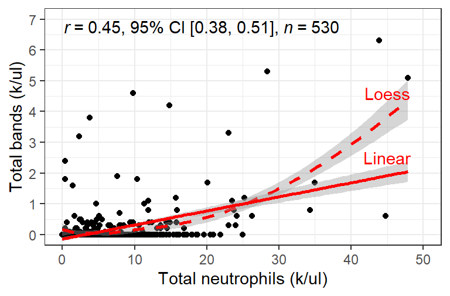

Figure 1: Scatterplot of Total Bands and Total Neutrophils With Linear and Loess Smoothing Curves (N = 530 Visits)

````markdown
```{r}
#| label: fig-visit-bands-neuts
#| fig-cap: !expr paste0("Scatterplot of Total Bands and Total Neutrophils ",
#|                       "With Linear and Loess Smoothing Curves ",
#|                       "(N = ", nrow(Final_Visits), " Visits)")
#| fig-width: 4
#| fig-height: 2.64
#| warning: false

Fig1 <- Final_Visits %>%
  ggplot(., aes(x = Total_Neutrophil, y = Total_Bands)) +
  geom_point() +
  stat_correlation(method = "pearson", small.r = TRUE, r.conf.level = 0.95,
                   use_label("R", "R.CI", "n")) +
  geom_smooth(method="loess", se = TRUE, fullrange = FALSE,
              level = 0.95, linetype = "dashed", col = "red") +
  geom_smooth(method="lm", se = TRUE, fullrange = FALSE, level = 0.95,
              linetype = "solid", col = "red") +
  theme_bw() +
  coord_cartesian(xlim = c(0, 50), ylim = c(0, 7), ) +
  scale_x_continuous(breaks = seq(from = 0, to = 50, by = 10)) +
  scale_y_continuous(breaks = seq(from = 0, to = 7, by = 1)) +
  xlab("Total neutrophils (k/ul)") +
  ylab("Total bands (k/ul)") +
  annotate(geom = "text", x =45, y = 4.6, label = "Loess", col = "red") +
  annotate(geom = "text", x =45, y = 2.5, label = "Linear", col = "red")

Fig1

# Export figure for use in journal submission
ggsave(filename = here(paste0("scripts/output/Figure_1.png")), plot = Fig1,
       device = "png", width = 4, height = 2.64, units = "in", dpi = 600)
```
````

**Tip**

Figure 1 will be Figure 1 in the manuscript we are preparing (Eliason et al., 2026). Note that the Pearson correlation is specifically a measure of linear association.

````markdown
```{r}
#| label: tbl-visit-describe-cont-by-Bandemia
#| tbl-cap: !expr paste0("Descriptive Statistics for Continuous Biomarker ",
#|                       "Variables by Bandemia (N = ", nrow(Final_Visits),
#|                       " Visits)")
#| message: false

VNames <- c("Total_WBC", "Total_Neutrophil", "Total_Bands", "BN_Ratio")
VNamesUnits <- c("Total_WBC (k/ul)",
                 "Total_Neutrophil (k/ul)",
                 "Total_Bands (k/ul)",
                 "BN_Ratio")

CNames <- c("Bandemia", "Variable", "N", "Mean", "SD", "Min", "Q25", "Q50",
            "Q75", "Max")

Final_Visits %>%
  select(Bandemia, Total_WBC, Total_Neutrophil, Total_Bands, BN_Ratio) %>%
  pivot_longer(cols = c(Total_WBC, Total_Neutrophil, Total_Bands, BN_Ratio),
               names_to = "Variable", values_to = "Value") %>%
  mutate(Variable = factor(Variable, levels = VNames)) %>%
  # Aggregate to one row per variable.
  group_by(Bandemia, Variable) %>%
  summarise(N = sum(!is.na(Value)),
            Mean = mean(Value, na.rm = TRUE),
            SD = sd(Value, na.rm = TRUE),
            Min = min(Value, na.rm = TRUE),
            Q25 = quantile(Value, probs = .25, na.rm = TRUE),
            Q50 = quantile(Value, probs = .50, na.rm = TRUE),
            Q75 = quantile(Value, probs = .75, na.rm = TRUE),
            Max = max(Value, na.rm = TRUE)) %>%
  ungroup() %>%
  mutate(Bandemia = factor(Bandemia, levels = 0:1, labels = c("No", "Yes")),
         Variable = factor(Variable, levels = VNames, labels = VNamesUnits)) %>%
  kable(., format = "html", digits = 1,
        col.names = CNames, row.names = FALSE) %>%
  kable_styling(bootstrap_options = c("striped", "hover", "condensed"),
                fixed_thead = T) %>%
  collapse_rows(., columns = 1, valign = "top", row_group_label_position = "stack")
```
````

Table 20: Descriptive Statistics for Continuous Biomarker Variables by Bandemia (N = 530 Visits)

| Bandemia | Variable | N | Mean | SD | Min | Q25 | Q50 | Q75 | Max |
| --- | --- | --- | --- | --- | --- | --- | --- | --- | --- |
| No | Total_WBC (k/ul) | 458 | 8.3 | 7.5 | 0.7 | 4.5 | 6.7 | 10.1 | 120.2 |
|  | Total_Neutrophil (k/ul) | 458 | 5.4 | 4.1 | 0.0 | 2.5 | 4.3 | 7.1 | 25.0 |
|  | Total_Bands (k/ul) | 458 | 0.0 | 0.0 | 0.0 | 0.0 | 0.0 | 0.0 | 0.1 |
|  | BN_Ratio | 457 | 0.0 | 0.0 | 0.0 | 0.0 | 0.0 | 0.0 | 0.2 |
| Yes | Total_WBC (k/ul) | 72 | 17.5 | 13.3 | 1.9 | 7.7 | 13.4 | 22.0 | 57.3 |
|  | Total_Neutrophil (k/ul) | 72 | 12.1 | 10.9 | 0.4 | 4.2 | 9.6 | 15.7 | 47.9 |
|  | Total_Bands (k/ul) | 72 | 1.0 | 1.4 | 0.2 | 0.3 | 0.4 | 1.1 | 6.3 |
|  | BN_Ratio | 72 | 0.3 | 0.9 | 0.0 | 0.0 | 0.1 | 0.1 | 6.0 |

Table 21 shows the univariate frequency distribution for drug (i.e., the number of times each drug was used).

````markdown
```{r}
#| label: tbl-drug-freq
#| tbl-cap: !expr paste0("Frequency Distribution for Drug Used (N = ",
#|                       nrow(Final_Visits), " Visits)")

DrugNames <- c("Vincristine", "Cyclophosphamide", "Doxorubicin")

Final_Visits %>%
  count(Drug) %>%
  rename(N_Visits = n) %>%
  mutate(Name = factor(Drug, levels = 1:3, labels = DrugNames),
         Percent = 100*(N_Visits/nrow(Final_Visits))) %>%
  select(Drug, Name, N_Visits, Percent) %>%
  kbl(digits = 1) %>%
  kable_styling()
```
````

Table 21: Frequency Distribution for Drug Used (N = 530 Visits)

| Drug | Name | N_Visits | Percent |
| --- | --- | --- | --- |
| 1 | Vincristine | 292 | 55.1 |
| 2 | Cyclophosphamide | 134 | 25.3 |
| 3 | Doxorubicin | 104 | 19.6 |

````markdown
```{r}
#| label: tbl-visit-describe-Dose-by-Drug
#| tbl-cap: !expr paste0("Descriptive Statistics for Dosage ",
#|                       "by Drug (N = ", nrow(Final_Visits),
#|                       " Visits)")
#| message: false

VNames <- c("Dose_mgpm2")
VNamesUnits <- c("Dosage (mg/m^2)")

CNames <- c("Drug", "Variable", "N", "Mean", "SD", "Min", "Q25", "Q50",
            "Q75", "Max")

Final_Visits %>%
  select(Name, Dose_mgpm2) %>%
  pivot_longer(cols = c(Dose_mgpm2),
               names_to = "Variable", values_to = "Value") %>%
  mutate(Variable = factor(VNames, levels = VNames)) %>%
  # Aggregate to one row per variable.
  group_by(Name) %>%
  summarise(Variable = VNames,
            N = sum(!is.na(Value)),
            Mean = mean(Value, na.rm = TRUE),
            SD = sd(Value, na.rm = TRUE),
            Min = min(Value, na.rm = TRUE),
            Q25 = quantile(Value, probs = .25, na.rm = TRUE),
            Q50 = quantile(Value, probs = .50, na.rm = TRUE),
            Q75 = quantile(Value, probs = .75, na.rm = TRUE),
            Max = max(Value, na.rm = TRUE)) %>%
  ungroup() %>%
  mutate(Variable = factor(Variable, levels = VNames, labels = VNamesUnits)) %>%
  kable(., format = "html", digits = 1,
        col.names = CNames, row.names = FALSE) %>%
  kable_styling(bootstrap_options = c("striped", "hover", "condensed"),
                fixed_thead = T)
```
````

Table 22: Descriptive Statistics for Dosage by Drug (N = 530 Visits)

| Drug | Variable | N | Mean | SD | Min | Q25 | Q50 | Q75 | Max |
| --- | --- | --- | --- | --- | --- | --- | --- | --- | --- |
| Vincristine | Dosage (mg/m^2) | 287 | 0.6 | 0.1 | 0.5 | 0.6 | 0.6 | 0.7 | 0.7 |
| Cyclophosphamide | Dosage (mg/m^2) | 133 | 242.3 | 17.4 | 180.0 | 240.0 | 250.0 | 250.0 | 300.0 |
| Doxorubicin | Dosage (mg/m^2) | 102 | 27.7 | 3.7 | 16.0 | 25.0 | 30.0 | 30.0 | 31.0 |

**Caution**

Dosage is a visit-level (L1) variable. The three drugs have very different ranges of typical values for dosage: The ranges differ by multiple orders of magnitude. Furthermore, there is no good reason expect that the dosage effect would have the same slope for across drugs. To use dosage in the model, we would need to center it, aggregate it to L2 means, then include main effect and interaction terms at both L1 and L2 between dosage and drug. We would also need to consider non-linear dosage effects. The interactions would permit the dosage effect to vary across drugs but this, plus considering non-linearity, would add a lot of parameters to the model. Given the sample size, that seems overly ambitious. It seems better to omit dosage effects from the model. I am not confident our data are sufficient to get reliable findings about dosage effects.

Table 23 shows the univariate frequency distribution for visit number.

````markdown
```{r}
#| label: tbl-visit-freq
#| tbl-cap: !expr paste0("Frequency Distribution for Visit Number (N = ",
#|                       nrow(Final_Visits), " Visits)")

Final_Visits %>%
  count(Visit_Number) %>%
  rename(N_Obs = n) %>%
  mutate(Percent = 100*(N_Obs/nrow(Final_Visits))) %>%
  select(Visit_Number, N_Obs, Percent) %>%
  kbl(digits = 1) %>%
  kable_styling()
```
````

Table 23: Frequency Distribution for Visit Number (N = 530 Visits)

| Visit_Number | N_Obs | Percent |
| --- | --- | --- |
| 1 | 88 | 16.6 |
| 2 | 79 | 14.9 |
| 3 | 71 | 13.4 |
| 4 | 59 | 11.1 |
| 5 | 57 | 10.8 |
| 6 | 48 | 9.1 |
| 7 | 44 | 8.3 |
| 8 | 41 | 7.7 |
| 9 | 40 | 7.5 |
| 10 | 3 | 0.6 |

## 3.3 Total Bands

Table 24 shows the frequency distribution for total bands in both its original units (x10.e3/uL=k/uL) and log-transformed units. It highlights the large proportion of zero values.

````markdown
```{r}
#| label: tbl-freq-bands
#| tbl-cap: "Frequency Distribution of Total Bands for All Visits"

Final_Visits %>%
  count(Total_Bands) %>%
  mutate(Log_Total_Bands = log(Total_Bands),
         Proportion = n/nrow(Final_Visits)) %>%
  select(Total_Bands, Log_Total_Bands, n, Proportion) %>%
  kable(digits = 3, col.names = c("Total Bands (k/ul)",
                                  "log(Total Bands [k/ul])",
                                  "n",
                                  "Proportion")) %>%
  kable_styling() %>%
  add_header_above(header = c("Raw Values", "Transformed Values" = 1,
                              "Frequency" = 2))
```
````

Table 24: Frequency Distribution of Total Bands for All Visits

| Raw Values Total Bands (k/ul) | Transformed Values log(Total Bands [k/ul]) | Frequency n | Frequency Proportion |
| --- | --- | --- | --- |
| 0.0 | -Inf | 423 | 0.798 |
| 0.1 | -2.303 | 35 | 0.066 |
| 0.2 | -1.609 | 12 | 0.023 |
| 0.3 | -1.204 | 12 | 0.023 |
| 0.4 | -0.916 | 13 | 0.025 |
| 0.5 | -0.693 | 4 | 0.008 |
| 0.6 | -0.511 | 5 | 0.009 |
| 0.7 | -0.357 | 1 | 0.002 |
| 0.8 | -0.223 | 4 | 0.008 |
| 1.0 | 0.000 | 2 | 0.004 |
| 1.1 | 0.095 | 2 | 0.004 |
| 1.2 | 0.182 | 2 | 0.004 |
| 1.6 | 0.470 | 1 | 0.002 |
| 1.7 | 0.531 | 2 | 0.004 |
| 1.8 | 0.588 | 2 | 0.004 |
| 1.9 | 0.642 | 1 | 0.002 |
| 2.4 | 0.875 | 1 | 0.002 |
| 3.2 | 1.163 | 1 | 0.002 |
| 3.3 | 1.194 | 1 | 0.002 |
| 3.8 | 1.335 | 1 | 0.002 |
| 4.2 | 1.435 | 1 | 0.002 |
| 4.6 | 1.526 | 1 | 0.002 |
| 5.1 | 1.629 | 1 | 0.002 |
| 5.3 | 1.668 | 1 | 0.002 |
| 6.3 | 1.841 | 1 | 0.002 |

Figure 2 shows the distribution total bands in the original units via a histogram. The heavy concentration of zero values makes it hard to see the shape of the distribution among the non-zero values.

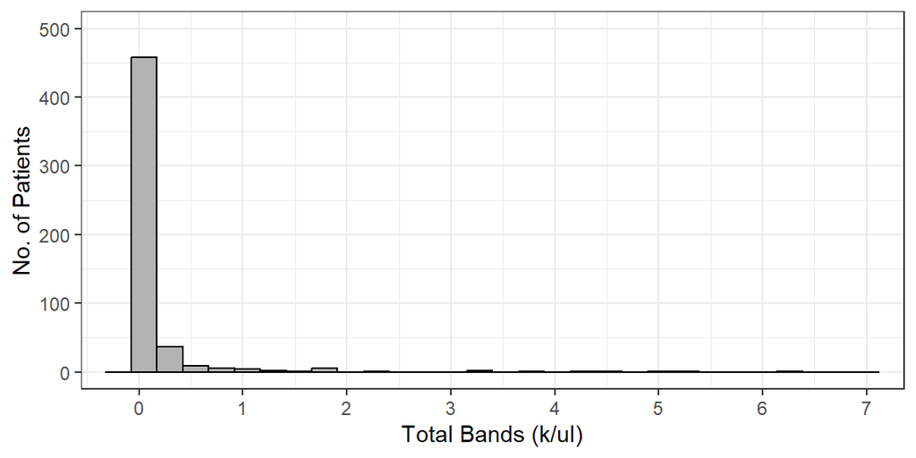

Figure 2: Distribution of Total Bands (k/ul) for All Visits.

````markdown
```{r}
#| label: fig-bands
#| fig-cap: Distribution of Total Bands (k/ul) for All Visits.
#| fig-width: 6
#| fig-height: 3
#| message: false

ggplot(Final_Visits, aes(x = Total_Bands)) +
  geom_histogram(aes(y=after_stat(count)), colour="black", fill="grey70") +
  theme_bw() +
  scale_x_continuous(limits = c(-0.2,7), n.breaks = 8, oob = function(x, limits) x) +
  scale_y_continuous(limits=c(-0.2, 500)) +
  xlab("Total Bands (k/ul)") +
  ylab("No. of Patients")
```
````

Figure 3 shows the distribution of log-transformed total bands via both a histogram and a boxplot with jittered data points. It includes data from all visits. In both graphs, the log equals -Infinity when total bands are 0, so we recoded these values to improve the figures and keep them compact and readable.

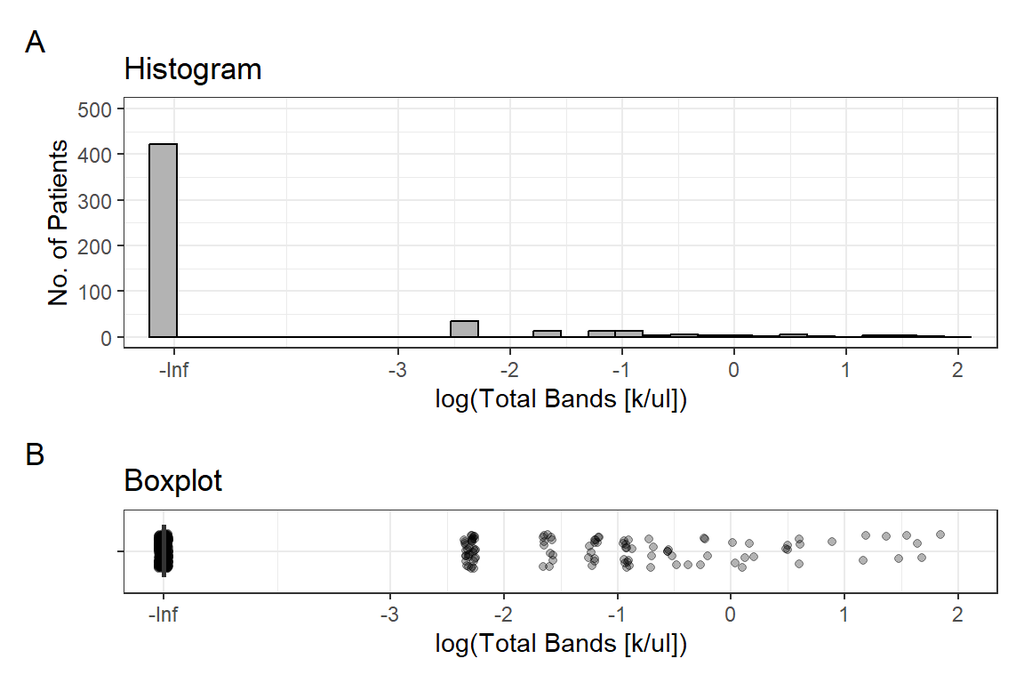

Figure 3: Distribution of log(Total Bands [k/ul]) for All Visits.

````markdown
```{r}
#| label: fig-log-bands
#| fig-cap: Distribution of log(Total Bands [k/ul]) for All Visits.
#| fig-width: 6
#| fig-height: 4
#| message: false

p1 <- Final_Visits %>%
  ggplot(., aes(x = log_Total_Bands)) +
  geom_histogram(aes(y=after_stat(count)), colour="black", fill="grey70") +
  theme_bw() +
  scale_x_continuous(limits = c(-5.1, 2), breaks = c(-5, -3:2),
                     labels = c("-Inf", as.character(-3:2)),
                     oob = function(x, limits) x) +
  scale_y_continuous(limits=c(-0.1, 500)) +
  xlab("log(Total Bands [k/ul])") +
  ylab("No. of Patients") +
  ggtitle("Histogram")

p2 <- Final_Visits %>%
  ggplot(., aes(x = log_Total_Bands, y = "")) +
  geom_jitter(alpha = .3, height = .25, width = .05) +
  geom_boxplot(outliers = FALSE, alpha = .5) +
  theme_bw() +
  coord_cartesian(xlim = c(-5, 2)) +
  scale_y_discrete( ) +
  scale_x_continuous(limits = c(-5.1, 2), breaks = c(-5, -3:2),
                     labels = c("-Inf", as.character(-3:2))) +
  xlab("log(Total Bands [k/ul])")  +
  ylab(" ")  +
  ggtitle("Boxplot")

p1 + p2 +
  plot_layout(nrow = 2, heights = c(3,1)) +
  plot_annotation(tag_levels = "A")
```
````

Meanwhile Figure 4 also shows log-transformed values of total bands, but it only uses data from visits with total bands > 0 to get a better look at the shape of the distribution.

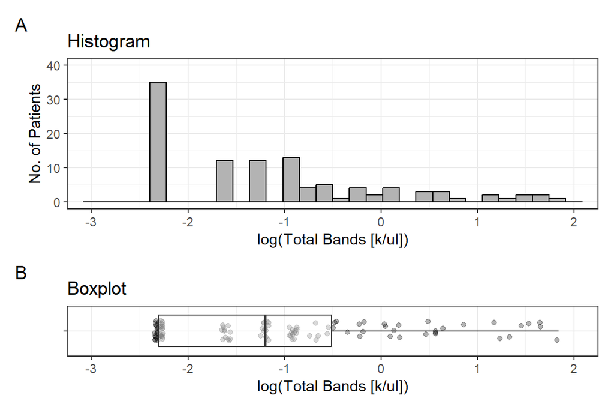

Figure 4: Distribution of log(Total Bands [k/ul]) for Visits with Total Bands > 0.

````markdown
```{r}
#| label: fig-log-bands-gt0
#| fig-cap: Distribution of log(Total Bands [k/ul]) for Visits with Total Bands > 0.
#| fig-width: 6
#| fig-height: 4
#| message: false

p1 <- Final_Visits %>%
  filter(Total_Bands > 0) %>%
  ggplot(., aes(x = log_Total_Bands)) +
  geom_histogram(aes(y=after_stat(count)), colour="black", fill="grey70") +
  theme_bw() +
  scale_x_continuous(limits = c(-3, 2), breaks = c(-3:2),
                     oob = function(x, limits) x) +
  scale_y_continuous(limits=c(-0.1, 40)) +
  xlab("log(Total Bands [k/ul])") +
  ylab("No. of Patients") +
  ggtitle("Histogram")

p2 <- Final_Visits %>%
  filter(Total_Bands > 0) %>%
  ggplot(., aes(x = log_Total_Bands, y = "")) +
  geom_jitter(alpha = .3, height = .25, width = .05) +
  geom_boxplot(outliers = FALSE, alpha = .5) +
  theme_bw() +
  coord_cartesian(xlim = c(-3, 2)) +
  scale_y_discrete( ) +
  scale_x_continuous(limits = c(-3, 2), breaks = c(-3:2)) +
  xlab("log(Total Bands [k/ul])")  +
  ylab(" ")  +
  ggtitle("Boxplot")

p1 + p2 +
  plot_layout(nrow = 2, heights = c(3,1)) +
  plot_annotation(tag_levels = "A")
```
````

### 3.3.1 Total Bands by Drug

Figure 5 shows the boxplot of **Total Bands (k/ul)**, categorized by drugs.

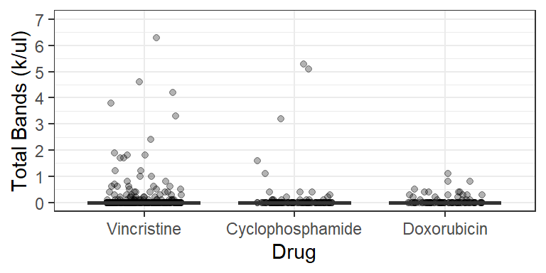

Figure 5: Boxplot of Total Bands [k/ul] by Drug for All Visits

````markdown
```{r}
#| label: fig-bands-drug
#| fig-cap: Boxplot of Total Bands [k/ul] by Drug for All Visits
#| fig-width: 4
#| fig-height: 2

Final_Visits %>%
  ggplot(., aes(x = Name, y = Total_Bands)) +
  geom_jitter(alpha = .3, width = .25, height = 0) +
  geom_boxplot(outliers = FALSE, alpha = .5) +
  theme_bw() +
  coord_cartesian(ylim = c(0, 7)) +
  scale_y_continuous(limits = c(0, 7), breaks = c(0:7)) +
  xlab("Drug")  +
  ylab("Total Bands (k/ul)")
```
````

Table 25 gives descriptive statistics for continuous biomarkers, broken down by drug name.

````markdown
```{r}
#| label: tbl-visit-describe-cont-by-Drug
#| tbl-cap: !expr paste0("Descriptive Statistics for Continuous Biomarker ",
#|                       "Variables by Drug (N = ", nrow(Final_Visits),
#|                       " Visits)")
#| message: false

VNames <- c("Total_WBC", "Total_Neutrophil", "Total_Bands", "BN_Ratio")
VNamesUnits <- c("Total_WBC (k/ul)",
                 "Total_Neutrophil (k/ul)",
                 "Total_Bands (k/ul)",
                 "BN_Ratio")

CNames <- c("Drug", "Variable", "N", "Mean", "SD", "Min", "Q25", "Q50",
            "Q75", "Max")

Final_Visits %>%
  select(Name, Total_WBC, Total_Neutrophil, Total_Bands, BN_Ratio) %>%
  pivot_longer(cols = c(Total_WBC, Total_Neutrophil, Total_Bands, BN_Ratio),
               names_to = "Variable", values_to = "Value") %>%
  mutate(Variable = factor(Variable, levels = VNames)) %>%
  # Aggregate to one row per variable.
  group_by(Name, Variable) %>%
  summarise(N = sum(!is.na(Value)),
            Mean = mean(Value, na.rm = TRUE),
            SD = sd(Value, na.rm = TRUE),
            Min = min(Value, na.rm = TRUE),
            Q25 = quantile(Value, probs = .25, na.rm = TRUE),
            Q50 = quantile(Value, probs = .50, na.rm = TRUE),
            Q75 = quantile(Value, probs = .75, na.rm = TRUE),
            Max = max(Value, na.rm = TRUE)) %>%
  ungroup() %>%
  mutate(Variable = factor(Variable, levels = VNames, labels = VNamesUnits)) %>%
  kable(., format = "html", digits = 1,
        col.names = CNames, row.names = FALSE) %>%
  kable_styling(bootstrap_options = c("striped", "hover", "condensed"),
                fixed_thead = T) %>%
  collapse_rows(., columns = 1, valign = "top", row_group_label_position = "stack")
```
````

Table 25: Descriptive Statistics for Continuous Biomarker Variables by Drug (N = 530 Visits)

| Drug | Variable | N | Mean | SD | Min | Q25 | Q50 | Q75 | Max |
| --- | --- | --- | --- | --- | --- | --- | --- | --- | --- |
| Vincristine | Total_WBC (k/ul) | 292 | 9.6 | 8.4 | 0.9 | 4.6 | 7.0 | 10.9 | 57.3 |
|  | Total_Neutrophil (k/ul) | 292 | 6.2 | 6.2 | 0.1 | 2.4 | 4.2 | 7.9 | 44.8 |
|  | Total_Bands (k/ul) | 292 | 0.2 | 0.7 | 0.0 | 0.0 | 0.0 | 0.0 | 6.3 |
|  | BN_Ratio | 292 | 0.1 | 0.4 | 0.0 | 0.0 | 0.0 | 0.0 | 6.0 |
| Cyclophosphamide | Total_WBC (k/ul) | 134 | 8.7 | 12.1 | 0.7 | 3.9 | 6.2 | 9.0 | 120.2 |
|  | Total_Neutrophil (k/ul) | 134 | 5.3 | 5.8 | 0.0 | 2.0 | 3.8 | 6.4 | 47.9 |
|  | Total_Bands (k/ul) | 134 | 0.1 | 0.7 | 0.0 | 0.0 | 0.0 | 0.0 | 5.3 |
|  | BN_Ratio | 133 | 0.0 | 0.2 | 0.0 | 0.0 | 0.0 | 0.0 | 1.4 |
| Doxorubicin | Total_WBC (k/ul) | 104 | 10.3 | 5.7 | 1.9 | 6.3 | 8.4 | 12.5 | 30.0 |
|  | Total_Neutrophil (k/ul) | 104 | 7.8 | 5.3 | 0.4 | 4.3 | 6.0 | 9.8 | 24.0 |
|  | Total_Bands (k/ul) | 104 | 0.1 | 0.2 | 0.0 | 0.0 | 0.0 | 0.0 | 1.1 |
|  | BN_Ratio | 104 | 0.0 | 0.0 | 0.0 | 0.0 | 0.0 | 0.0 | 0.1 |

Figure 6 shows the boxplot of **log(Total bands) (k/ul)**, categorized by drugs, where -Inf means total bands = 0.

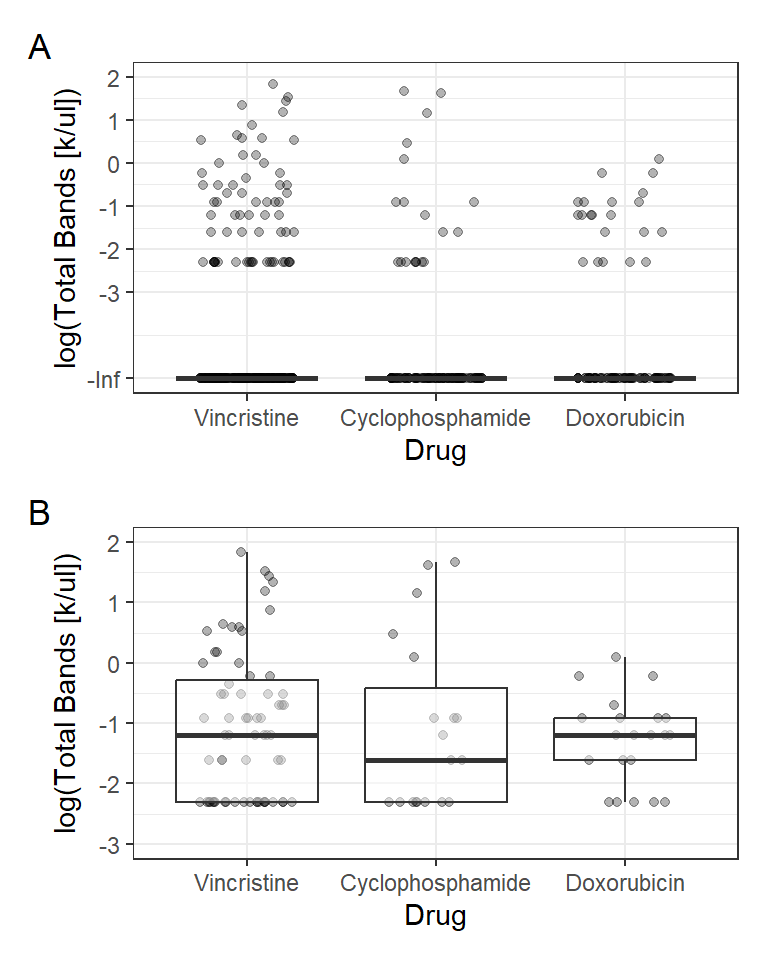

Figure 6: Boxplots of log(Total Bands [k/ul]) by drug for (A) all visits and (B) visits with Total Bands > 0 k/ul.

````markdown
```{r}
#| label: fig-log-total-bands-drug
#| fig-cap: Boxplots of log(Total Bands [k/ul]) by drug for (A) all visits and
#|          (B) visits with Total Bands > 0 k/ul.
#| fig-width: 4
#| fig-height: 5

p1 <- Final_Visits %>%
  ggplot(., aes(x = Name, y = log_Total_Bands)) +
  geom_jitter(alpha = .3, width = .25, height = 0) +
  geom_boxplot(outliers = FALSE, alpha = .5) +
  theme_bw() +
  coord_cartesian(ylim = c(-5, 2)) +
  scale_y_continuous(limits = c(-5.1, 2), breaks = c(-5, -3:2),
                     labels = c("-Inf", as.character(-3:2))) +
  xlab("Drug")  +
  ylab("log(Total Bands [k/ul])")


p2 <- Final_Visits %>%
  filter(Total_Bands > 0) %>%
  ggplot(., aes(x = Name, y = log_Total_Bands)) +
  geom_jitter(alpha = .3, width = .25, height = 0) +
  geom_boxplot(outliers = FALSE, alpha = .5) +
  theme_bw() +
  # coord_cartesian(ylim = c(-5, 2)) +
  # scale_y_continuous(limits = c(-5.1, 2), breaks = c(-5, -3:2),
  #                    labels = c("-Inf", as.character(-3:2))) +
  coord_cartesian(ylim = c(-3, 2)) +
  scale_y_continuous(limits = c(-3, 2), breaks = c(-3:2)) +
  xlab("Drug")  +
  ylab("log(Total Bands [k/ul])")

p1 + p2 +
 plot_layout(nrow = 2) +
 plot_annotation(tag_levels = "A")
```
````

Table 26 and Figure 7 show the number and percent of CBCs by band neutrophil category for each drug used.

````markdown
```{r}
#| label: tbl-drug-Band-Category
#| tbl-cap: Band Category Frequency by Prior Drug Administered

Drug1_N <- Final_Visits %>% filter(Drug == 1) %>% nrow()
Drug2_N <- Final_Visits %>% filter(Drug == 2) %>% nrow()
Drug3_N <- Final_Visits %>% filter(Drug == 3) %>% nrow()

Drug_Band_Category <- Final_Visits %>%
  xtabs(~Band_Category + Drug, data = .) %>%
  addmargins(margin = 1) %>%
  as.data.frame() %>%
  rename(N = Freq) %>%
  mutate(Name = factor(Drug, labels = DrugNames),
         Percent = case_when(Drug == 1 ~ 100*N/Drug1_N,
                             Drug == 2 ~ 100*N/Drug2_N,
                             Drug == 3 ~ 100*N/Drug3_N)) %>%
  relocate(Drug, Name, Band_Category)

Drug_Band_Category %>%
  kable(digits = 1,
        col.names = c("Drug", "Name", "Band Category", "N", "Percent")) %>%
  kable_styling()
```
````

Table 26: Band Category Frequency by Prior Drug Administered

| Drug | Name | Band Category | N | Percent |
| --- | --- | --- | --- | --- |
| 1 | Vincristine | Absent (0.0 k/ul) | 225 | 77.1 |
| 1 | Vincristine | Present (<= 0.1 k/ul) | 22 | 7.5 |
| 1 | Vincristine | Bandemia (> 0.1 k/ul) | 45 | 15.4 |
| 1 | Vincristine | Sum | 292 | 100.0 |
| 2 | Cyclophosphamide | Absent (0.0 k/ul) | 115 | 85.8 |
| 2 | Cyclophosphamide | Present (<= 0.1 k/ul) | 8 | 6.0 |
| 2 | Cyclophosphamide | Bandemia (> 0.1 k/ul) | 11 | 8.2 |
| 2 | Cyclophosphamide | Sum | 134 | 100.0 |
| 3 | Doxorubicin | Absent (0.0 k/ul) | 83 | 79.8 |
| 3 | Doxorubicin | Present (<= 0.1 k/ul) | 5 | 4.8 |
| 3 | Doxorubicin | Bandemia (> 0.1 k/ul) | 16 | 15.4 |
| 3 | Doxorubicin | Sum | 104 | 100.0 |

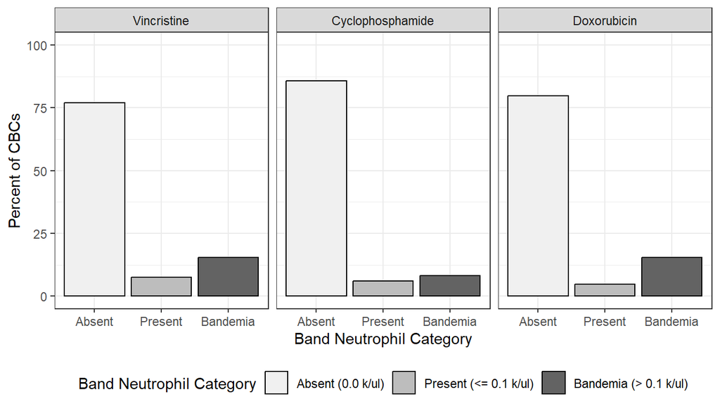

Figure 7: Band Category Distribution by Prior Drug Administered

````markdown
```{r}
#| label: fig-drug-Band-Category
#| fig-cap: Band Category Distribution by Prior Drug Administered
#| fig-width: 7
#| fig-height: 4
#| message: false

Drug_Band_Category %>%
  filter(Band_Category != "Sum") %>%
ggplot(., aes(x = Band_Category, y = Percent, fill = Band_Category)) +
  geom_bar(stat = "identity", col = "black") +
  scale_fill_brewer(name = "Band Neutrophil Category", palette = "Greys") +
  xlab("Band Neutrophil Category") +
  scale_x_discrete(labels=c("Absent (0.0 k/ul)" = "Absent",
                            "Present (<= 0.1 k/ul)" = "Present",
                            "Bandemia (> 0.1 k/ul)" = "Bandemia")) +
  ylab("Percent of CBCs") +
  scale_y_continuous(limits=c(0, 100)) +
  facet_wrap(~ Name) +
  theme_bw()+
  theme(legend.position = "bottom")
```
````

### 3.3.2 Total Bands by Visit Number

Table 27 provides the mean and standard deviation of **Total Bands** for each visit. From this data, we can observe that the mean value of Total bands tends to decrease over time.

````markdown
```{r}
#| label: tbl-bands-visit
#| tbl-cap: Summary of Total Bands (k/ul) By VIsit Number

Total_Bands_counts <- Final_Visits %>%
  group_by(Visit_Number) %>%
   summarise(N = sum(!is.na(Total_Bands)),
    Mean = round(mean(Total_Bands, na.rm = TRUE),4),
    SD= round(sd(Total_Bands, na.rm = TRUE),4),
    Min = min(Total_Bands, na.rm = TRUE),
    Q25 = quantile(Total_Bands, probs = .25, na.rm = TRUE),
    Q50 = quantile(Total_Bands, probs = .50, na.rm = TRUE),
    Q75 = quantile(Total_Bands, probs = .75, na.rm = TRUE),
    Max= max(Total_Bands, na.rm = TRUE))

Total_Bands_counts %>%
  kable(digits = 1) %>%
  kable_styling(bootstrap_options = c("striped", "hover", "condensed"),
                fixed_thead = T)
```
````

Table 27: Summary of Total Bands (k/ul) By VIsit Number

| Visit_Number | N | Mean | SD | Min | Q25 | Q50 | Q75 | Max |
| --- | --- | --- | --- | --- | --- | --- | --- | --- |
| 1 | 88 | 0.3 | 0.9 | 0 | 0 | 0 | 0.1 | 6.3 |
| 2 | 79 | 0.2 | 0.8 | 0 | 0 | 0 | 0.0 | 5.1 |
| 3 | 71 | 0.2 | 0.9 | 0 | 0 | 0 | 0.0 | 5.3 |
| 4 | 59 | 0.1 | 0.3 | 0 | 0 | 0 | 0.0 | 1.2 |
| 5 | 57 | 0.1 | 0.6 | 0 | 0 | 0 | 0.0 | 4.2 |
| 6 | 48 | 0.0 | 0.1 | 0 | 0 | 0 | 0.0 | 0.6 |
| 7 | 44 | 0.0 | 0.1 | 0 | 0 | 0 | 0.0 | 0.8 |
| 8 | 41 | 0.0 | 0.0 | 0 | 0 | 0 | 0.0 | 0.2 |
| 9 | 40 | 0.1 | 0.2 | 0 | 0 | 0 | 0.0 | 1.2 |
| 10 | 3 | 0.1 | 0.2 | 0 | 0 | 0 | 0.1 | 0.3 |

Figure 8 shows the boxplot of total bands (k/ul) for each visit, Figure 9 shows the corresponding boxplots for log-transformed values both for all visits and the subset of visits with total bands > 0. In the log scale, -Inf corresponds to total bands = 0 k/ul.

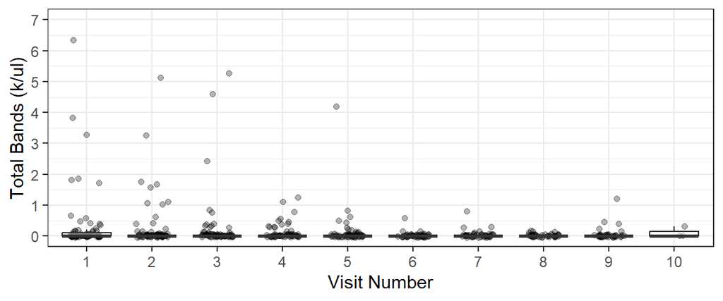

Figure 8: Boxplot of Total Bands (k/ul) by Visit Number

````markdown
```{r}
#| label: fig-bands-visit
#| fig-cap: Boxplot of Total Bands (k/ul) by Visit Number
#| fig-width: 6
#| fig-height: 2.5

Final_Visits %>%
  ggplot(., aes(x = factor(Visit_Number), y = Total_Bands,
                group = Visit_Number)) +
  geom_jitter(alpha = .3, width = .25, height = .05) +
  geom_boxplot(outliers = FALSE, alpha = .5) +
  theme_bw() +
  coord_cartesian(ylim = c(0, 7)) +
  scale_y_continuous(limits = c(-.1, 7), breaks = c(0:7)) +
  xlab("Visit Number") +
  ylab("Total Bands (k/ul)")
```
````

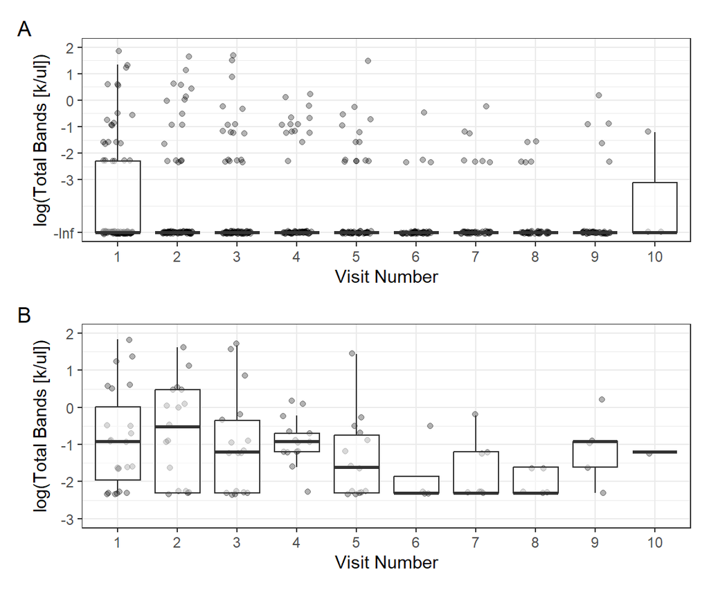

Figure 9: Boxplot of Total Bands (k/ul) by Visit Number for (A) All Visits and (B) Visits with Total Bands > 0 k/ul.

````markdown
```{r}
#| label: fig-log-bands-visit
#| fig-cap: Boxplot of Total Bands (k/ul) by Visit Number for (A) All Visits and
#|          (B) Visits with Total Bands > 0 k/ul.
#| fig-width: 6
#| fig-height: 5

p1 <- Final_Visits %>%
  ggplot(., aes(x = factor(Visit_Number), y = log_Total_Bands,
                group = Visit_Number)) +
  geom_jitter(alpha = .3, width = .25, height = .05) +
  geom_boxplot(outliers = FALSE, alpha = .5) +
  theme_bw() +
  coord_cartesian(ylim = c(-5, 2)) +
  scale_y_continuous(limits = c(-5.1, 2), breaks = c(-5, -3:2),
                     labels = c("-Inf", as.character(-3:2))) +
  xlab("Visit Number") +
  ylab("log(Total Bands [k/ul])")

p2 <- Final_Visits %>%
  filter(Total_Bands > 0) %>%
  ggplot(., aes(x = factor(Visit_Number), y = log_Total_Bands,
                group = Visit_Number)) +
  geom_jitter(alpha = .3, width = .25, height = .05) +
  geom_boxplot(outliers = FALSE, alpha = .5) +
  theme_bw() +
  # coord_cartesian(ylim = c(-5, 2)) +
  # scale_y_continuous(limits = c(-5.1, 2), breaks = c(-5, -3:2),
  #                    labels = c("-Inf", as.character(-3:2))) +
  coord_cartesian(ylim = c(-3, 2)) +
  scale_y_continuous(limits = c(-3, 2), breaks = c(-3:2)) +
  xlab("Visit Number") +
  ylab("log(Total Bands [k/ul])")

p1 + p2 +
 plot_layout(nrow = 2) +
 plot_annotation(tag_levels = "A")
```
````

**Note**

Figure 9 (or either of its panels alone) may become a figure in the manuscript. We used a variation of panel A as Figure 3 in the prior manuscript, which we are now revising for submission to another journal.

````markdown
```{r}
#| label: tbl-bands-eq0-visit
#| tbl-cap: Number and Proportion of Visits With Total Bands = 0 k/ul by Visit.

Final_Visits %>%
  mutate(Zero_Bands = Total_Bands == 0) %>%
  group_by(Visit_Number) %>%
  summarize(n = n(),
            Zero_Bands_N = sum(Zero_Bands),
            Zero_Bands_Proportion = mean(Zero_Bands)) %>%
  kable(digits = 3,
        col.names = c("Visit Number", "Total N", "N", "Proportion")) %>%
  kable_styling() %>%
  add_header_above(header = c(" " = 2, "Total Bands = 0" = 2))
```
````

Table 28: Number and Proportion of Visits With Total Bands = 0 k/ul by Visit.

| Visit Number | Total N | Total Bands = 0 N | Total Bands = 0 Proportion |
| --- | --- | --- | --- |
| 1 | 88 | 65 | 0.739 |
| 2 | 79 | 62 | 0.785 |
| 3 | 71 | 54 | 0.761 |
| 4 | 59 | 45 | 0.763 |
| 5 | 57 | 43 | 0.754 |
| 6 | 48 | 44 | 0.917 |
| 7 | 44 | 37 | 0.841 |
| 8 | 41 | 36 | 0.878 |
| 9 | 40 | 35 | 0.875 |
| 10 | 3 | 2 | 0.667 |

#### Drug 1

Table 29 provides the mean and standard deviation of **Total bands** for individuals using Drug 1 at each visit time.

````markdown
```{r}
#| label: tbl-total_bands_by_visit_drug1
#| tbl-cap: Summary of total bands (x100/ul) for individuals using Drug 1 at each visit time.

Final_Visits %>%
  filter(Drug==1) %>%
  group_by(Visit_Number) %>%
  summarise(mean = round(mean(Total_Bands_Rescaled, na.rm = TRUE),4),
            sd= round(sd(Total_Bands_Rescaled, na.rm = TRUE),4),
            min = min(Total_Bands_Rescaled, na.rm = TRUE),
            max= max(Total_Bands_Rescaled, na.rm = TRUE)) %>%
  kable(digits = 2) %>%
  kable_styling()
```
````

Table 29: Summary of total bands (x100/ul) for individuals using Drug 1 at each visit time.

| Visit_Number | mean | sd | min | max |
| --- | --- | --- | --- | --- |
| 1 | 2.92 | 9.45 | 0 | 63 |
| 2 | 4.20 | 6.47 | 0 | 18 |
| 3 | 1.84 | 7.03 | 0 | 46 |
| 4 | 1.70 | 3.95 | 0 | 12 |
| 5 | 1.50 | 6.25 | 0 | 42 |
| 6 | 0.50 | 1.61 | 0 | 6 |
| 7 | 0.55 | 1.54 | 0 | 8 |
| 8 | 0.11 | 0.33 | 0 | 1 |
| 9 | 0.60 | 2.30 | 0 | 12 |
| 10 | 0.00 | NA | 0 | 0 |

Figure 10 is a boxplot that visualize the information.

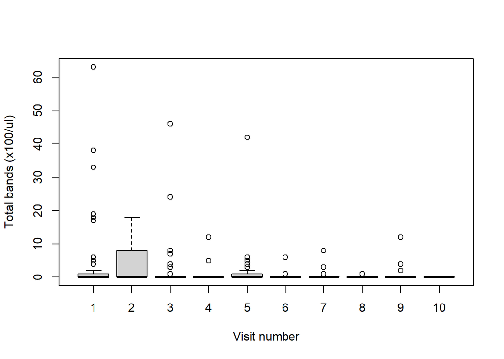

Figure 10: Boxplot of total bands (x100/ul) for each visit time for drug 1

````markdown
```{r}
#| label: fig-boxplot_total_bands
#| fig-cap: "Boxplot of total bands (x100/ul) for each visit time for drug 1"
boxplot(Total_Bands_Rescaled~Visit_Number,
        data=Final_Visits[Final_Visits$Drug==1,],
        xlab="Visit number",
        ylab="Total bands (x100/ul)")
```
````

Figure 11 shows the boxplot of log(total bands x100/ul) for individuals using Drug 1 at each visit time, where -Inf means total bands=0.

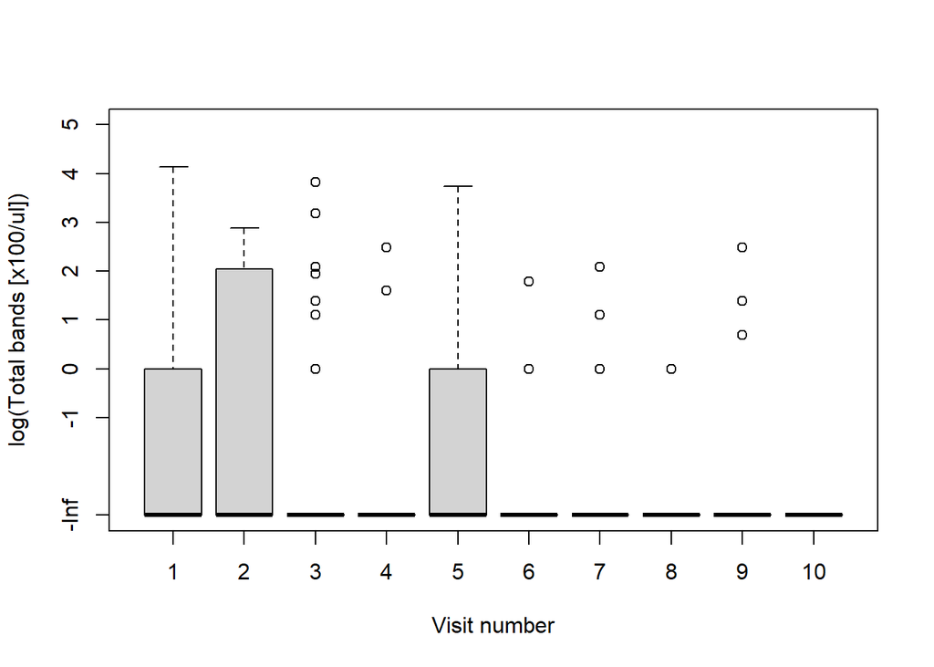

Figure 11: Boxplot of log(total bands [x100/ul]) for each visit time for those using drug 1.

````markdown
```{r}
#| label: fig-total_bands_by_visit_drug1_log
#| fig-cap: "Boxplot of log(total bands [x100/ul]) for each visit time for those using drug 1."

boxplot(log_Total_Bands_Rescaled~Visit_Number,
        data=Final_Visits[Final_Visits$Drug==1,],
        xlab="Visit number",
        ylab="log(Total bands [x100/ul])", ylim = c(-3, 5), yaxt = "n")
axis_positions <- c(-3, seq(-1, 5, length.out = 7))
axis_labels <- c("-Inf", formatC(seq(-1, 5, length.out = 7),
                                 format = "f", digits = 0))
axis(2, at = axis_positions, labels = axis_labels)
```
````

Figure 12 shows the boxplot of log(total bands x100/ul) for individuals using Drug 1 at each visit time and only include those with total bands>0.

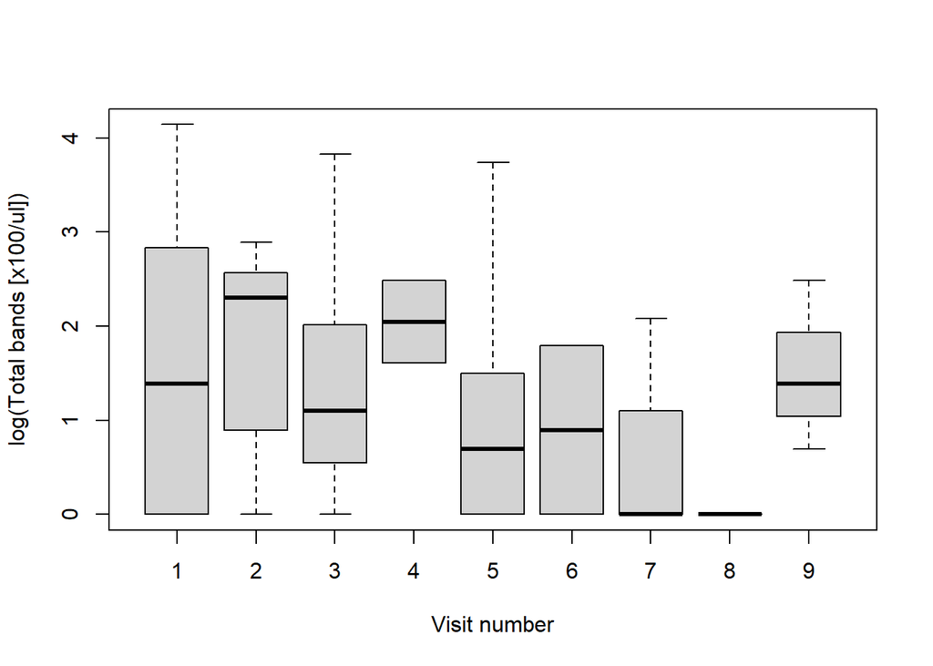

Figure 12: Boxplot of log(total bands [x100/ul]) for each visit time for those using drug 1 (only include those with total bands > 0).

````markdown
```{r}
#| label: fig-total_bands_by_visit_drug1_log_part
#| fig-cap: "Boxplot of log(total bands [x100/ul]) for each visit time for those using drug 1 (only include those with total bands > 0)."

boxplot(log_Total_Bands_Rescaled[Total_Bands_Rescaled > 0] ~
          Visit_Number[Total_Bands_Rescaled>0],
        data=Final_Visits[Final_Visits$Drug==1,],
        xlab="Visit number",
        ylab="log(Total bands [x100/ul])")
```
````

Table 30 shows the number and proportion of instances where total bands equal 0 for each drug used.

````markdown
```{r}
#| label: tbl-total_bands_by_visit_drug1_zero
#| tbl-cap: Number and proportion of instances where total bands equal 0 for each visit time for those using drug 1.

Final_Visits %>%
  filter(Drug == 1) %>%
  mutate(Zero_Bands = Total_Bands == 0) %>%
  group_by(Visit_Number) %>%
  summarize(n = n(),
            Zero_Bands_N = sum(Zero_Bands),
            Zero_Bands_Proportion = mean(Zero_Bands)) %>%
  kable(digits = 3,
        col.names = c("Visit Number", "Total N", "N", "Proportion")) %>%
  kable_styling() %>%
  add_header_above(header = c(" " = 2, "Total Bands = 0" = 2))
```
````

Table 30: Number and proportion of instances where total bands equal 0 for each visit time for those using drug 1.

| Visit Number | Total N | Total Bands = 0 N | Total Bands = 0 Proportion |
| --- | --- | --- | --- |
| 1 | 79 | 57 | 0.722 |
| 2 | 15 | 8 | 0.533 |
| 3 | 55 | 44 | 0.800 |
| 4 | 10 | 8 | 0.800 |
| 5 | 46 | 34 | 0.739 |
| 6 | 14 | 12 | 0.857 |
| 7 | 33 | 26 | 0.788 |
| 8 | 9 | 8 | 0.889 |
| 9 | 30 | 27 | 0.900 |
| 10 | 1 | 1 | 1.000 |

````markdown
```{r}
#| label: drug

drug1 <- Final_Visits %>% filter(Drug==1)
drug2 <- Final_Visits %>% filter(Drug==2)
drug3 <- Final_Visits %>% filter(Drug==3)
```
````

Figure 13 shows the times of using drug 1 at each visit number.

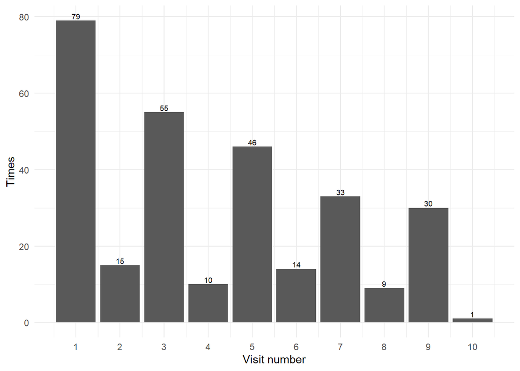

Figure 13: Times of using drug 1 at each visit number

````markdown
```{r}
#| label: fig-visit_times_of_drug_1
#| fig-cap: Times of using drug 1 at each visit number

drug_counts <- drug1 %>%
  group_by(Visit_Number) %>%
  summarise(Count = n())
ggplot(drug_counts, aes(x = Visit_Number, y = Count)) +
  geom_bar(stat = "identity") +
  geom_text(aes(label = Count), vjust = -0.3, size = 2.5) +
  labs(x = "Visit number", y = "Times") +
  scale_x_continuous(breaks = c(1:16))+
  theme_minimal()
```
````

#### Drug 2

Table 31 provides the mean and standard deviation of **Total bands** for individuals using Drug 2 at each visit time.

````markdown
```{r}
#| label: tbl-total_bands_by_visit_drug2
#| tbl-cap: Summary of total bands (x100/ul) for individuals using Drug 2 at each visit time.

Final_Visits %>%
  filter(Drug==2) %>%
  group_by(Visit_Number) %>%
  summarise(mean = round(mean(Total_Bands_Rescaled, na.rm = TRUE),4),
            sd= round(sd(Total_Bands_Rescaled, na.rm = TRUE),4),
            min = min(Total_Bands_Rescaled, na.rm = TRUE),
            max= max(Total_Bands_Rescaled, na.rm = TRUE)) %>%
  kable(digits = 2) %>%
  kable_styling()
```
````

Table 31: Summary of total bands (x100/ul) for individuals using Drug 2 at each visit time.

| Visit_Number | mean | sd | min | max |
| --- | --- | --- | --- | --- |
| 1 | 0.25 | 0.71 | 0 | 2 |
| 2 | 1.92 | 7.77 | 0 | 51 |
| 3 | 9.67 | 21.29 | 0 | 53 |
| 4 | 0.00 | NA | 0 | 0 |
| 5 | 0.14 | 0.38 | 0 | 1 |
| 6 | 0.06 | 0.24 | 0 | 1 |
| 7 | 0.00 | 0.00 | 0 | 0 |
| 8 | 0.00 | 0.00 | 0 | 0 |
| 9 | 0.14 | 0.38 | 0 | 1 |
| 10 | 1.50 | 2.12 | 0 | 3 |

Figure 14 is a boxplot that visualize the information.

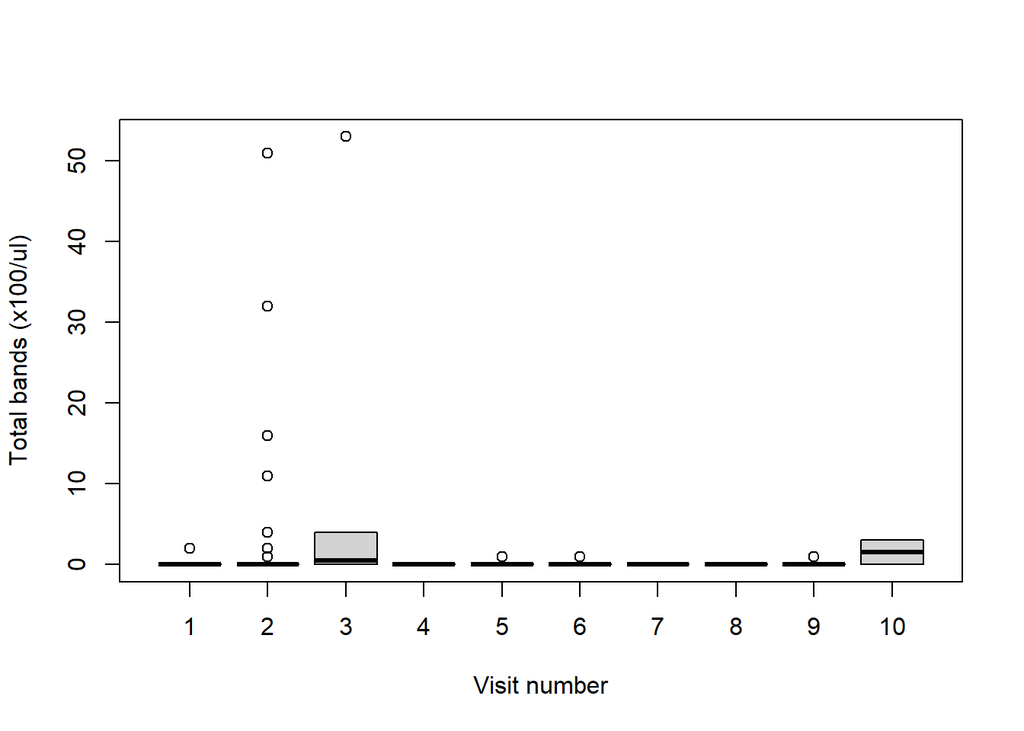

Figure 14: Boxplot of total bands (x100/ul) for each visit time for drug 2

````markdown
```{r}
#| label: fig-boxplot_drug_2
#| fig-cap: "Boxplot of total bands (x100/ul) for each visit time for drug 2"

boxplot(Total_Bands_Rescaled~Visit_Number,
        data=Final_Visits[Final_Visits$Drug==2,],
        xlab="Visit number",
        ylab="Total bands (x100/ul)")
```
````

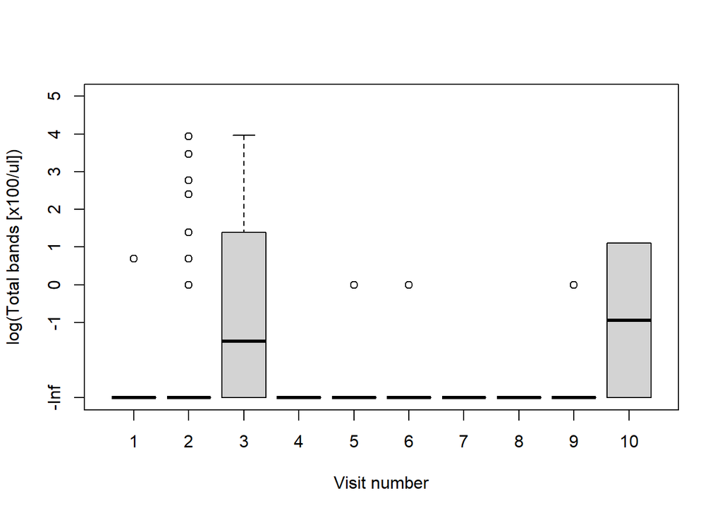

Figure 15: Boxplot of log(total bands [x100/ul]) for each visit time for those using drug 2.

````markdown
```{r}
#| label: fig-total_bands_by_visit_drug2_log
#| fig-cap: Boxplot of log(total bands [x100/ul]) for each visit time for those using drug 2.

boxplot(log_Total_Bands_Rescaled~Visit_Number,
        data=Final_Visits[Final_Visits$Drug==2,],
        xlab="Visit number",
        ylab="log(Total bands [x100/ul])", ylim = c(-3, 5), yaxt = "n")
axis_positions <- c(-3, seq(-1, 5, length.out = 7))
axis_labels <- c("-Inf", formatC(seq(-1, 5, length.out = 7),
                                 format = "f", digits = 0))
axis(2, at = axis_positions, labels = axis_labels)
```
````

Figure 16 shows the boxplot of log(total bands x100/ul) for individuals using Drug 2 at each visit time and only include those with total bands>0.

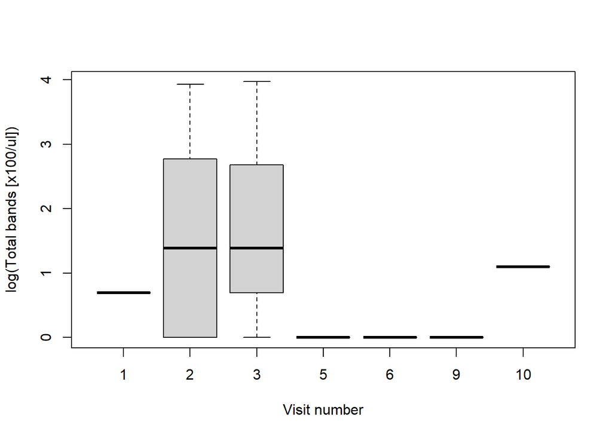

Figure 16: Boxplot of log(total bands [x100/ul]) for each visit time for those using drug 2 (only include those with total bands > 0).

````markdown
```{r}
#| label: fig-total_bands_by_visit_drug2_log_part
#| fig-cap: Boxplot of log(total bands [x100/ul]) for each visit time for those using drug 2 (only include those with total bands \> 0).

boxplot(log_Total_Bands_Rescaled[Total_Bands_Rescaled > 0] ~
          Visit_Number[Total_Bands_Rescaled>0],
        data=Final_Visits[Final_Visits$Drug==2,],
        xlab="Visit number",
        ylab="log(Total bands [x100/ul])")
```
````

Table 32 shows the number and proportion of instances where total bands equal 0 for each drug used.

````markdown
```{r}
#| label: tbl-total_bands_by_visit_drug2_zero
#| tbl-cap: Number and proportion of instances where total bands equal 0 for each visit time for those using drug 2.

Final_Visits %>%
  filter(Drug == 2) %>%
  mutate(Zero_Bands = Total_Bands == 0) %>%
  group_by(Visit_Number) %>%
  summarize(n = n(),
            Zero_Bands_N = sum(Zero_Bands),
            Zero_Bands_Proportion = mean(Zero_Bands)) %>%
  kable(digits = 3,
        col.names = c("Visit Number", "Total N", "N", "Proportion")) %>%
  kable_styling() %>%
  add_header_above(header = c(" " = 2, "Total Bands = 0" = 2))
```
````

Table 32: Number and proportion of instances where total bands equal 0 for each visit time for those using drug 2.

| Visit Number | Total N | Total Bands = 0 N | Total Bands = 0 Proportion |
| --- | --- | --- | --- |
| 1 | 8 | 7 | 0.875 |
| 2 | 64 | 54 | 0.844 |
| 3 | 6 | 3 | 0.500 |
| 4 | 1 | 1 | 1.000 |
| 5 | 7 | 6 | 0.857 |
| 6 | 33 | 31 | 0.939 |
| 7 | 3 | 3 | 1.000 |
| 8 | 3 | 3 | 1.000 |
| 9 | 7 | 6 | 0.857 |
| 10 | 2 | 1 | 0.500 |

Figure 17 shows the times of using drug 2 at each visit number

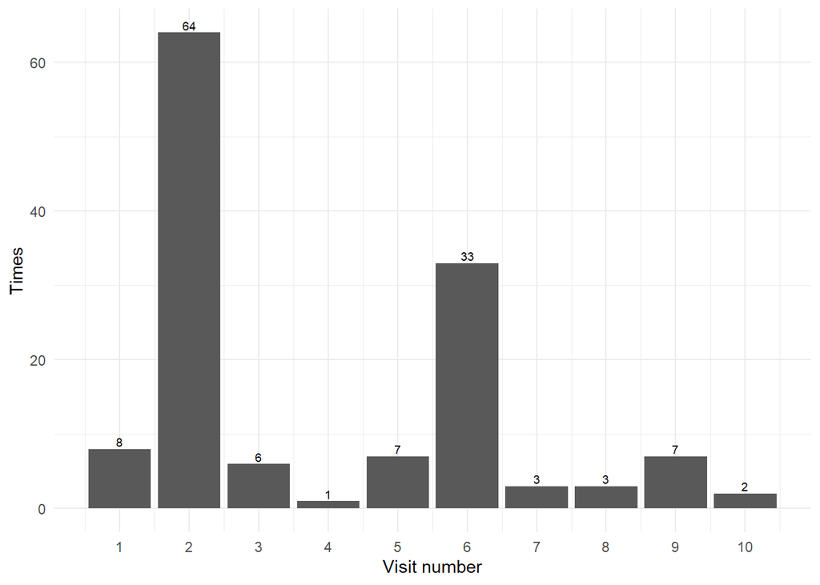

Figure 17: Times of using drug 2 at each visit number

````markdown
```{r}
#| label: fig-visit_times_of_drug_2
#| fig-cap: Times of using drug 2 at each visit number

drug_counts <- drug2 %>%
  group_by(Visit_Number) %>%
  summarise(Count = n())
ggplot(drug_counts, aes(x = Visit_Number, y = Count)) +
  geom_bar(stat = "identity") +
  geom_text(aes(label = Count), vjust = -0.3, size = 2.5) +
  labs(x = "Visit number", y = "Times") +
  scale_x_continuous(breaks = c(1:16))+
  theme_minimal()
```
````

#### Drug 3

Table 33 provides the mean and standard deviation of **Total bands** for individuals using Drug 3 at each visit time.

````markdown
```{r}
#| label: tbl-total_bands_by_visit_drug3
#| tbl-cap: Summary of total bands (x100/ul) for individuals using Drug 3 at each visit time.

Final_Visits %>%
  filter(Drug==3) %>%
  group_by(Visit_Number) %>%
  summarise(mean = round(mean(Total_Bands_Rescaled, na.rm = TRUE),4),
            sd= round(sd(Total_Bands_Rescaled, na.rm = TRUE),4),
            min = min(Total_Bands_Rescaled, na.rm = TRUE),
            max= max(Total_Bands_Rescaled, na.rm = TRUE)) %>%
  kable(digits = 2) %>%
  kable_styling()
```
````

Table 33: Summary of total bands (x100/ul) for individuals using Drug 3 at each visit time.

| Visit_Number | mean | sd | min | max |
| --- | --- | --- | --- | --- |
| 1 | 0.00 | NA | 0 | 0 |
| 3 | 0.50 | 0.97 | 0 | 3 |
| 4 | 1.06 | 2.28 | 0 | 11 |
| 5 | 2.00 | 4.00 | 0 | 8 |
| 6 | 0.00 | NA | 0 | 0 |
| 7 | 0.00 | 0.00 | 0 | 0 |
| 8 | 0.21 | 0.56 | 0 | 2 |
| 9 | 1.33 | 2.31 | 0 | 4 |

Figure 18 is a boxplot that visualize the information.

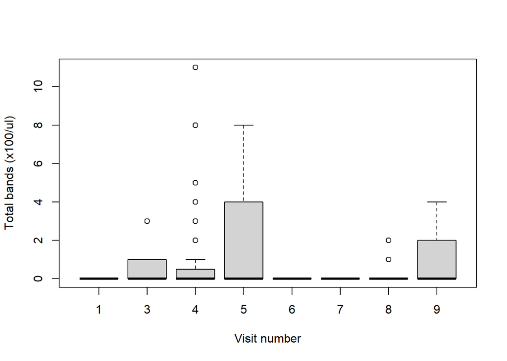

````markdown
```{r}
#| label: fig-boxplot_drug_3
#| #| fig-cap: "Boxplot of total bands (x100/ul) for each visit time for drug 3"

boxplot(Total_Bands_Rescaled~Visit_Number,
        data=Final_Visits[Final_Visits$Drug==3,],
        xlab="Visit number",
        ylab="Total bands (x100/ul)")
```
````

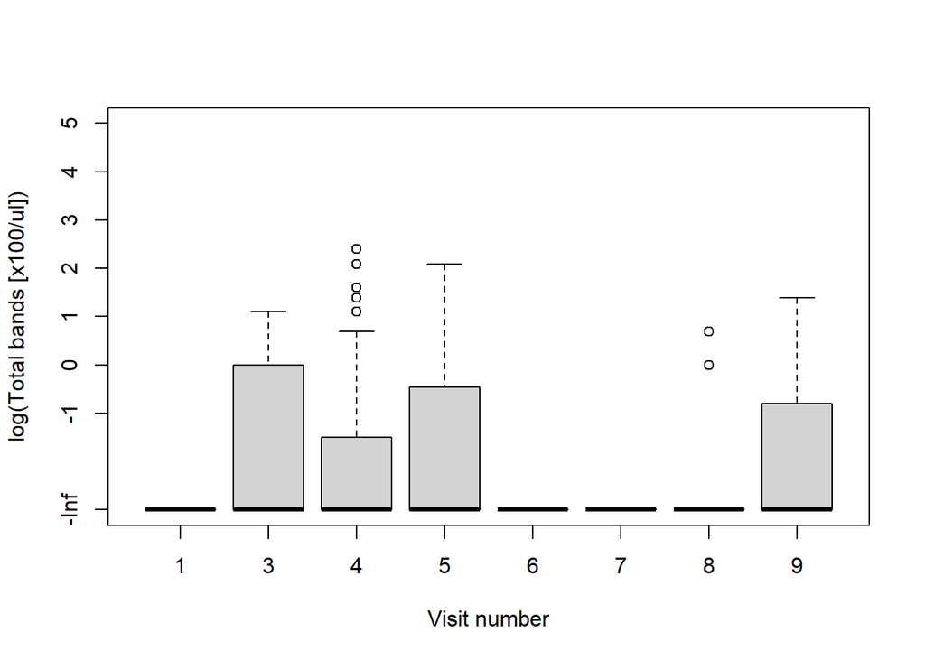

Figure 19: Boxplot of log(total bands [x100/ul]) for each visit time for those using drug 3.

````markdown
```{r}
#| label: fig-total_bands_by_visit_drug3_log
#| fig-cap: Boxplot of log(total bands [x100/ul]) for each visit time for those using drug 3.

boxplot(log_Total_Bands_Rescaled~Visit_Number,
        data=Final_Visits[Final_Visits$Drug==3,],
        xlab="Visit number",
        ylab="log(Total bands [x100/ul])", ylim = c(-3, 5), yaxt = "n")
axis_positions <- c(-3, seq(-1, 5, length.out = 7))
axis_labels <- c("-Inf", formatC(seq(-1, 5, length.out = 7),
                                 format = "f", digits = 0))
axis(2, at = axis_positions, labels = axis_labels)
```
````

Figure 20 shows the boxplot of log(total bands x100/ul) for individuals using Drug 3 at each visit time and only include those with total bands>0.

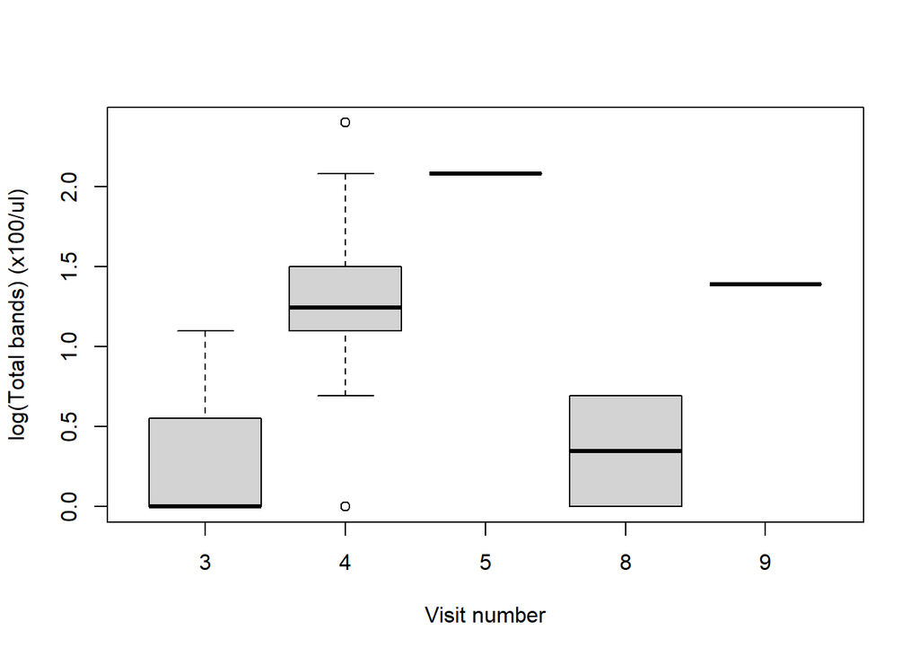

Figure 20: Boxplot of log(total bands x100/ul) for each visit time for those using drug 3.

````markdown
```{r}
#| label: fig-total_bands_by_visit_drug3_log_part
#| fig-cap: Boxplot of log(total bands x100/ul) for each visit time for those using drug 3.
boxplot(log_Total_Bands_Rescaled[Total_Bands_Rescaled>0]~Visit_Number[Total_Bands_Rescaled>0],data=Final_Visits[Final_Visits$Drug==3,],xlab="Visit number",ylab="log(Total bands) (x100/ul)")
```
````

Table 34 shows the number and proportion of instances where total bands equal 0 for each drug used.

````markdown
```{r}
#| label: tbl-total_bands_by_visit_drug3_zero
#| tbl-cap: Number and proportion of instances where total bands equal 0 for each visit time for those using drug 3.

Final_Visits %>%
  filter(Drug == 3) %>%
  mutate(Zero_Bands = Total_Bands == 0) %>%
  group_by(Visit_Number) %>%
  summarize(n = n(),
            Zero_Bands_N = sum(Zero_Bands),
            Zero_Bands_Proportion = mean(Zero_Bands)) %>%
  kable(digits = 3,
        col.names = c("Visit Number", "Total N", "N", "Proportion")) %>%
  kable_styling() %>%
  add_header_above(header = c(" " = 2, "Total Bands = 0" = 2))
```
````

Table 34: Number and proportion of instances where total bands equal 0 for each visit time for those using drug 3.

| Visit Number | Total N | Total Bands = 0 N | Total Bands = 0 Proportion |
| --- | --- | --- | --- |
| 1 | 1 | 1 | 1.000 |
| 3 | 10 | 7 | 0.700 |
| 4 | 48 | 36 | 0.750 |
| 5 | 4 | 3 | 0.750 |
| 6 | 1 | 1 | 1.000 |
| 7 | 8 | 8 | 1.000 |
| 8 | 29 | 25 | 0.862 |
| 9 | 3 | 2 | 0.667 |

Figure 21 shows the times of using drug 3 at each visit number

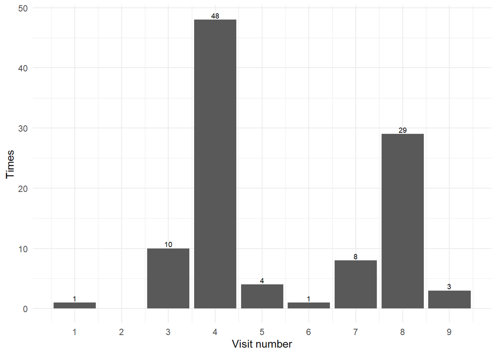

Figure 21: Times of using drug 3 at each visit number

````markdown
```{r}
#| label: fig-visit_times_of_drug_3
#| fig-cap: Times of using drug 3 at each visit number

drug_counts <- drug3 %>%
  group_by(Visit_Number) %>%
  summarise(Count = n())
ggplot(drug_counts, aes(x = Visit_Number, y = Count)) +
  geom_bar(stat = "identity") +
  geom_text(aes(label = Count), vjust = -0.3, size = 2.5) +
  labs(x = "Visit number", y = "Times") +
  scale_x_continuous(breaks = c(1:16))+
  theme_minimal()
```
````

## 3.4 Bandemia by Visit Number

Table 35 and Figure 22 show that there is not a simple functional form for the relationship between visit number and bandemia rate. It is probably not viable to model a visit effect in this study because of this and because of the structural association of visit number with which drug was used (see Figure 23 in the Drug Sequences section). Also note that the bandemia rate at visit 10 should be interpreted with caution because of the tiny sample size.

````markdown
```{r}
#| label: tbl-bandemia-by-visit
#| tbl-cap: Bandemia Rate by Visit Number

Final_Visits %>%
  group_by(Visit_Number) %>%
  summarize(N = n(),
            Bandemia = mean(Bandemia)) %>%
  kable(format = "html", digits = 2) %>%
  kable_styling()
```
````

Table 35: Bandemia Rate by Visit Number

| Visit_Number | N | Bandemia |
| --- | --- | --- |
| 1 | 88 | 0.19 |
| 2 | 79 | 0.15 |
| 3 | 71 | 0.15 |
| 4 | 59 | 0.22 |
| 5 | 57 | 0.14 |
| 6 | 48 | 0.02 |
| 7 | 44 | 0.07 |
| 8 | 41 | 0.05 |
| 9 | 40 | 0.10 |
| 10 | 3 | 0.33 |

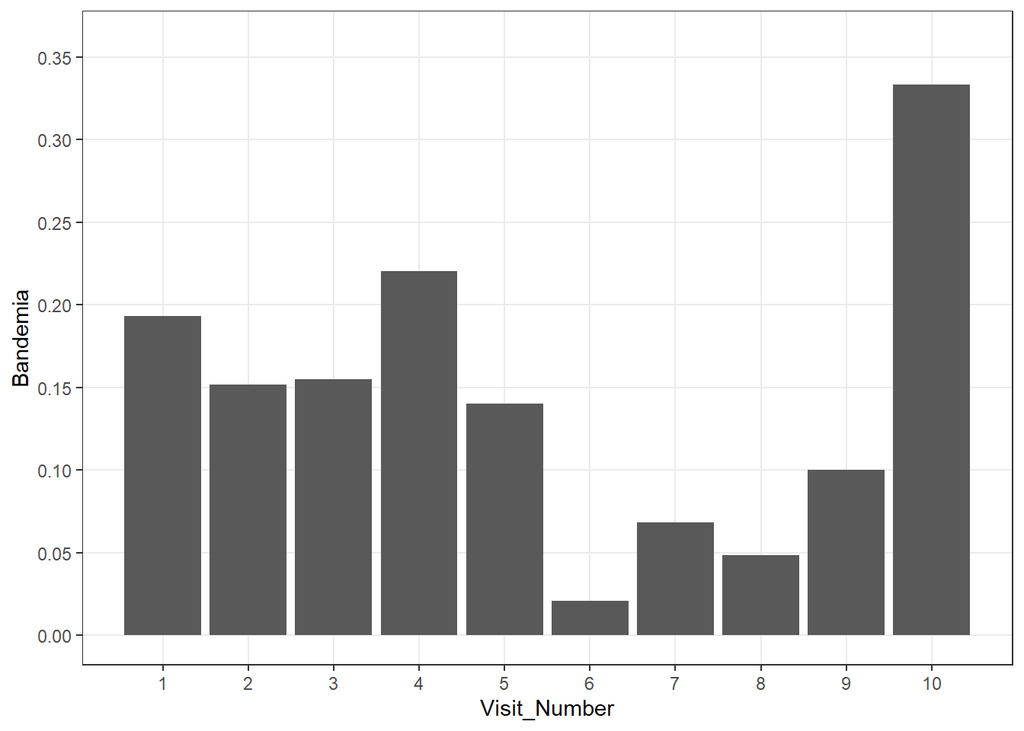

Figure 22: Bandemia Rate by Visit Number

````markdown
```{r}
#| label: fig-bandemia-by-visit
#| fig-cap: Bandemia Rate by Visit Number

Final_Visits %>%
  group_by(Visit_Number) %>%
  summarize(Bandemia = mean(Bandemia)) %>%
  ggplot(., aes(x = Visit_Number, y = Bandemia)) +
  geom_bar(stat = "identity") +
  scale_x_continuous(breaks = c(1:10), minor_breaks = NULL) +
  scale_y_continuous(limits = c(0,.36),
                     breaks = seq(from = 0, to = .35, by = .05),
                     minor_breaks = NULL) +
  theme_bw()
```
````

## 3.5 Total White Blood Cells (WBC)

Table 36 provides the mean and standard deviation of total WBC for each visit number.

````markdown
```{r}
#| label: tbl-WBC-visit
#| tbl-cap: Summary of total white blood cells (x1000/uL) for each visit time.
Final_Visits %>%
  group_by(Visit_Number) %>%
  summarise(mean = round(mean(Total_WBC, na.rm = TRUE),4),
            sd= round(sd(Total_WBC, na.rm = TRUE),4),
            min = min(Total_WBC, na.rm = TRUE),
            max= max(Total_WBC, na.rm = TRUE)) %>%
  kable(digits = 2) %>%
  kable_styling()
```
````

Table 36: Summary of total white blood cells (x1000/uL) for each visit time.

| Visit_Number | mean | sd | min | max |
| --- | --- | --- | --- | --- |
| 1 | 11.73 | 11.56 | 1.1 | 57.3 |
| 2 | 10.65 | 15.04 | 0.7 | 120.2 |
| 3 | 9.51 | 6.89 | 1.3 | 40.3 |
| 4 | 10.93 | 6.97 | 0.9 | 30.0 |
| 5 | 7.66 | 5.84 | 1.0 | 28.9 |
| 6 | 6.36 | 4.68 | 1.4 | 29.1 |
| 7 | 6.57 | 3.10 | 2.6 | 15.7 |
| 8 | 8.62 | 5.35 | 3.4 | 36.0 |
| 9 | 10.88 | 7.01 | 2.6 | 35.7 |
| 10 | 12.30 | 4.88 | 8.0 | 17.6 |

## 3.6 Neutrophils (neuts)

Table 37 provides the mean and standard deviation of **Total neutrophil** for each visit time.

````markdown
```{r}
#| label: tbl-total_neutrophil_by_visit
#| tbl-cap: Summary of total neutrophil for each visit time.

Final_Visits %>%
  group_by(Visit_Number) %>%
  summarise(mean = round(mean(Total_Neutrophil, na.rm = TRUE),4),
            sd= round(sd(Total_Neutrophil, na.rm = TRUE),4),
            min = min(Total_Neutrophil, na.rm = TRUE),
            max= max(Total_Neutrophil, na.rm = TRUE)) %>%
  kable(digits = 2) %>%
  kable_styling()
```
````

Table 37: Summary of total neutrophil for each visit time.

| Visit_Number | mean | sd | min | max |
| --- | --- | --- | --- | --- |
| 1 | 7.15 | 8.02 | 0.4 | 44.8 |
| 2 | 6.46 | 7.12 | 0.0 | 47.9 |
| 3 | 6.72 | 6.09 | 0.4 | 34.3 |
| 4 | 8.25 | 6.26 | 0.1 | 24.0 |
| 5 | 4.98 | 4.71 | 0.2 | 25.0 |
| 6 | 4.04 | 3.97 | 0.8 | 24.2 |
| 7 | 4.27 | 2.51 | 0.8 | 11.9 |
| 8 | 5.54 | 2.94 | 1.0 | 16.2 |
| 9 | 7.84 | 5.20 | 0.7 | 25.2 |
| 10 | 9.33 | 4.19 | 5.9 | 14.0 |

## 3.7 Bandemia Grade

````markdown
```{r}
#| label: tbl-Bandemia-Grade
#| tbl-cap: Frequency Distribution of Bandemia Grade
#| warning: false

Final_Visits %>%
  mutate(Bandemia_Grade = factor(Bandemia_Grade, levels = 0:5)) %>%
  group_by(Bandemia_Grade, .drop = FALSE) %>%
  summarize(Min = min(Total_Bands),
            Max = max(Total_Bands),
            N = n(),
            Proportion = N/nrow(Final_Visits)) %>%
  ungroup() %>%
  mutate(MSUVDL_Range = fct_recode(Bandemia_Grade, "0.00-0.10" = "0",
                                   "0.11-0.29" = "1", "0.30-0.59" = "2",
                                   "0.60-0.99" = "3", ">= 1.00" = "4",
                                   "death" = "5" )) %>%
  select(Bandemia_Grade, MSUVDL_Range, Min, Max, N, Proportion) %>%
  kable(digits = 3, col.names = c("Bandemia Grade",
                                  "MSUVDL Reference Range (k/ul)", "Min", "Max",
                                  "N", "Proportion")) %>%
  kable_styling() %>%
  add_header_above(header = c(" " = 2, "Observed Total_Bands (k/ul)" = 2, " " = 2))
```
````

Table 38: Frequency Distribution of Bandemia Grade

| Bandemia Grade | MSUVDL Reference Range (k/ul) | Observed Total_Bands (k/ul) Min | Observed Total_Bands (k/ul) Max | N | Proportion |
| --- | --- | --- | --- | --- | --- |
| 0 | 0.00-0.10 | 0.0 | 0.1 | 458 | 0.864 |
| 1 | 0.11-0.29 | 0.2 | 0.2 | 12 | 0.023 |
| 2 | 0.30-0.59 | 0.3 | 0.5 | 29 | 0.055 |
| 3 | 0.60-0.99 | 0.6 | 0.8 | 10 | 0.019 |
| 4 | >= 1.00 | 1.0 | 6.3 | 21 | 0.040 |
| 5 | death | Inf | -Inf | 0 | 0.000 |

## 3.8 Drug Sequences

Table 39 shows the frequency of occurrence for each unique sequence of drug use observed. Each row represents a group of dogs who got the same sequence of drugs across the 10 visits of interest. Ideally, the most common sequence will match the intended CHOP protocol sequence for using the drugs. The table is sorted in descending order by sequence frequency (`N_Dogs`) then by `N_Visits`, which is the number of visits in the pattern that were actually observed. Columns `V1` to `V10` show the drug number used at a specific visit number in the given sequence. Because only data about drugs 1-3 were included, it is possible that blanks in the middle of a sequence were visits where some other drug was administered.

````markdown
```{r}
#| label: tbl-visit-patterns
#| tbl-cap: !expr paste0("Frequency Distribution of Drug Sequence ",
#|                       "(N = ", length(unique(Final_Visits$Patient)),
#|                       " Patients)")
#| warning: false

options(knitr.kable.NA = '-')

Final_Visits %>%
  select(Patient, Visit_Number, Drug) %>%
  rename(VN = Visit_Number) %>%
  pivot_wider(id_cols = "Patient", names_from = "VN", names_prefix = "V",
              values_from = "Drug") %>%
  group_by(V1, V2, V3, V4, V5, V6, V7, V8, V9, V10) %>%
  summarize(N_Dogs = n()) %>%
  ungroup() %>%
  rowwise() %>%
  mutate(N_Visits = sum(!is.na(c_across(V1:V10)))) %>%
  ungroup() %>%
  arrange(desc(N_Dogs), desc(N_Visits)) %>%
  rowid_to_column(var = "SequenceID") %>%
  relocate(SequenceID, N_Dogs, N_Visits) %>%
  kable() %>%
  kable_styling() %>%
  add_header_above(header = c(" " = 3, "Drug Sequence (Drug Used by Visit Number)" = 10))
```
````

Table 39: Frequency Distribution of Drug Sequence (N = 90 Patients)

| SequenceID | N_Dogs | N_Visits | Drug Sequence (Drug Used by Visit Number) V1 | Drug Sequence (Drug Used by Visit Number) V2 | Drug Sequence (Drug Used by Visit Number) V3 | Drug Sequence (Drug Used by Visit Number) V4 | Drug Sequence (Drug Used by Visit Number) V5 | Drug Sequence (Drug Used by Visit Number) V6 | Drug Sequence (Drug Used by Visit Number) V7 | Drug Sequence (Drug Used by Visit Number) V8 | Drug Sequence (Drug Used by Visit Number) V9 | Drug Sequence (Drug Used by Visit Number) V10 |
| --- | --- | --- | --- | --- | --- | --- | --- | --- | --- | --- | --- | --- |
| 1 | 25 | 9 | 1 | 2 | 1 | 3 | 1 | 2 | 1 | 3 | 1 | - |
| 2 | 8 | 2 | 1 | 2 | - | - | - | - | - | - | - | - |
| 3 | 8 | 1 | 1 | - | - | - | - | - | - | - | - | - |
| 4 | 6 | 5 | 1 | 2 | 1 | 3 | 1 | - | - | - | - | - |
| 5 | 5 | 3 | 1 | 2 | 1 | - | - | - | - | - | - | - |
| 6 | 4 | 4 | 1 | 2 | 1 | 3 | - | - | - | - | - | - |
| 7 | 3 | 9 | 2 | 1 | 3 | 1 | 2 | 1 | 3 | 1 | 2 | - |
| 8 | 3 | 3 | 1 | 2 | 3 | - | - | - | - | - | - | - |
| 9 | 2 | 9 | 1 | 2 | 1 | 3 | 2 | 1 | 3 | 1 | 2 | - |
| 10 | 2 | 6 | 1 | 2 | 1 | 3 | 1 | 1 | - | - | - | - |
| 11 | 2 | 2 | 2 | 1 | - | - | - | - | - | - | - | - |
| 12 | 2 | 2 | - | 1 | 2 | - | - | - | - | - | - | - |
| 13 | 1 | 10 | 1 | 2 | 1 | 3 | 1 | 2 | 1 | 3 | 1 | 2 |
| 14 | 1 | 9 | 1 | 1 | 1 | 3 | 1 | 2 | 1 | 3 | 1 | - |
| 15 | 1 | 9 | 1 | 1 | 2 | 1 | 3 | 1 | 2 | 1 | 3 | - |
| 16 | 1 | 9 | 1 | 1 | 3 | 1 | 2 | 1 | 3 | 1 | 2 | - |
| 17 | 1 | 9 | 1 | 2 | 1 | 3 | 1 | 2 | 1 | 2 | 1 | - |
| 18 | 1 | 9 | 1 | 2 | 1 | 3 | 1 | 2 | 1 | 3 | 2 | - |
| 19 | 1 | 9 | 1 | - | 2 | 1 | 3 | 1 | 2 | 1 | 3 | 1 |
| 20 | 1 | 8 | 1 | 2 | 1 | 3 | 1 | 2 | 1 | 3 | - | - |
| 21 | 1 | 8 | 1 | 2 | 1 | 3 | 1 | 2 | 3 | 2 | - | - |
| 22 | 1 | 8 | 1 | 2 | 1 | - | 1 | 2 | 1 | - | 1 | 2 |
| 23 | 1 | 8 | 1 | - | 2 | 1 | 3 | 1 | 2 | 1 | 3 | - |
| 24 | 1 | 7 | 1 | 2 | 1 | 3 | 1 | 1 | 3 | - | - | - |
| 25 | 1 | 7 | 1 | 2 | 1 | 3 | 1 | 2 | 1 | - | - | - |
| 26 | 1 | 6 | 1 | 2 | 1 | 3 | 1 | 3 | - | - | - | - |
| 27 | 1 | 6 | 2 | 1 | 3 | 1 | 2 | 1 | - | - | - | - |
| 28 | 1 | 6 | 3 | 1 | 2 | 1 | 3 | 1 | - | - | - | - |
| 29 | 1 | 5 | 1 | 1 | 3 | 1 | 1 | - | - | - | - | - |
| 30 | 1 | 5 | 1 | - | - | - | 1 | - | 1 | 2 | 1 | - |
| 31 | 1 | 5 | 2 | 1 | 1 | 2 | 1 | - | - | - | - | - |
| 32 | 1 | 3 | 2 | 1 | 3 | - | - | - | - | - | - | - |

Table 40 shows the subset of drug sequences that deviate from the CHOP protocol by using cyclosphosphamide at visit 1.

````markdown
```{r}
#| label: tbl-visit-patterns-subset
#| tbl-cap: !expr paste0("Subset of Drug Sequences That Used Cyclosphosphamide ",
#|                       "at Visit 1 ",
#|                       "(N = ", length(unique(Final_Visits$Patient)),
#|                       " Patients)")
#| warning: false

options(knitr.kable.NA = '-')

Final_Visits %>%
  select(Patient, Visit_Number, Drug) %>%
  rename(VN = Visit_Number) %>%
  pivot_wider(id_cols = "Patient", names_from = "VN", names_prefix = "V",
              values_from = "Drug") %>%
  group_by(V1, V2, V3, V4, V5, V6, V7, V8, V9, V10) %>%
  summarize(N_Dogs = n()) %>%
  ungroup() %>%
  rowwise() %>%
  mutate(N_Visits = sum(!is.na(c_across(V1:V10)))) %>%
  ungroup() %>%
  arrange(desc(N_Dogs), desc(N_Visits)) %>%
  rowid_to_column(var = "SequenceID") %>%
  relocate(SequenceID, N_Dogs, N_Visits) %>%
  filter(V1 == 2) %>%
  kable() %>%
  kable_styling() %>%
  add_header_above(header = c(" " = 3, "Drug Sequence (Drug Used by Visit Number)" = 10))
```
````

Table 40: Subset of Drug Sequences That Used Cyclosphosphamide at Visit 1 (N = 90 Patients)

| SequenceID | N_Dogs | N_Visits | Drug Sequence (Drug Used by Visit Number) V1 | Drug Sequence (Drug Used by Visit Number) V2 | Drug Sequence (Drug Used by Visit Number) V3 | Drug Sequence (Drug Used by Visit Number) V4 | Drug Sequence (Drug Used by Visit Number) V5 | Drug Sequence (Drug Used by Visit Number) V6 | Drug Sequence (Drug Used by Visit Number) V7 | Drug Sequence (Drug Used by Visit Number) V8 | Drug Sequence (Drug Used by Visit Number) V9 | Drug Sequence (Drug Used by Visit Number) V10 |
| --- | --- | --- | --- | --- | --- | --- | --- | --- | --- | --- | --- | --- |
| 7 | 3 | 9 | 2 | 1 | 3 | 1 | 2 | 1 | 3 | 1 | 2 | - |
| 11 | 2 | 2 | 2 | 1 | - | - | - | - | - | - | - | - |
| 27 | 1 | 6 | 2 | 1 | 3 | 1 | 2 | 1 | - | - | - | - |
| 31 | 1 | 5 | 2 | 1 | 1 | 2 | 1 | - | - | - | - | - |
| 32 | 1 | 3 | 2 | 1 | 3 | - | - | - | - | - | - | - |

````markdown
```{r}
#| label: tbl-v1-v2
#| tbl-cap: !expr paste0("Contingency Table of Drug Used at Visit 1 by Drug ",
#|                       "Used at Visit 2 ",
#|                       "(N = ", length(unique(Final_Visits$Patient)),
#|                       " Patients)")
#| warning: false

Final_Visits %>%
  select(Patient, Visit_Number, Name) %>%
  rename(VN = Visit_Number) %>%
  pivot_wider(id_cols = "Patient", names_from = "VN", names_prefix = "Drug_at_Visit_",
              values_from = "Name") %>%
  xtabs(~Drug_at_Visit_1 + Drug_at_Visit_2, addNA = TRUE, data = .) %>%
  addmargins() %>%
  kable(col.names = c("Drug at Visit 1", "Vincristine", "Cyclophosphamide",
                      "Doxorubicin", "<NA>", "Sum")) %>%
  kable_styling() %>%
  add_header_above(header = c(" " = 1, "Drug at Visit 2" = 4, " "))
```
````

Table 41: Contingency Table of Drug Used at Visit 1 by Drug Used at Visit 2 (N = 90 Patients)

| Drug at Visit 1 | Drug at Visit 2 Vincristine | Drug at Visit 2 Cyclophosphamide | Drug at Visit 2 Doxorubicin | Drug at Visit 2 <NA> | Sum |
| --- | --- | --- | --- | --- | --- |
| Vincristine | 4 | 64 | 0 | 11 | 79 |
| Cyclophosphamide | 8 | 0 | 0 | 0 | 8 |
| Doxorubicin | 1 | 0 | 0 | 0 | 1 |
| - | 2 | 0 | 0 | 0 | 2 |
| Sum | 15 | 64 | 0 | 11 | 90 |

To summarize how often each drug was used at each visit, see Table 42 for raw counts, and Figure 23 for a visualization of the percentages. These outputs strongly suggest that fitting a model that could disentangle temporal effects from drug effects would be very difficult in this sample because the conditional distribution of which drug was administered varies considerably by visit due to structured CHOP protocol: visits 1, 3, 5, 7, and 9 mostly used vincristine, visits 2 and 6 mostly used cyclophosphamide, and visits 4 and 8 mostly used doxorubicin. That confounds drug with visit.

````markdown
```{r}
#| label: tbl-visit-drug
#| tbl-cap: Number of Records by Visit and Drug

xtabs(~Visit_Number + Drug, data = Final_Visits) %>%
  addmargins() %>%
  kable(col.names = c("Visit", "1 Vincristine", "2 Cyclophosphamide",
                      "3 Doxorubicin", "Sum")) %>%
  kable_styling() %>%
  add_header_above(., header = c(" ", "Drug" = 3, " "))
```
````

Table 42: Number of Records by Visit and Drug

| Visit | Drug 1 Vincristine | Drug 2 Cyclophosphamide | Drug 3 Doxorubicin | Sum |
| --- | --- | --- | --- | --- |
| 1 | 79 | 8 | 1 | 88 |
| 2 | 15 | 64 | 0 | 79 |
| 3 | 55 | 6 | 10 | 71 |
| 4 | 10 | 1 | 48 | 59 |
| 5 | 46 | 7 | 4 | 57 |
| 6 | 14 | 33 | 1 | 48 |
| 7 | 33 | 3 | 8 | 44 |
| 8 | 9 | 3 | 29 | 41 |
| 9 | 30 | 7 | 3 | 40 |
| 10 | 1 | 2 | 0 | 3 |
| Sum | 292 | 134 | 104 | 530 |

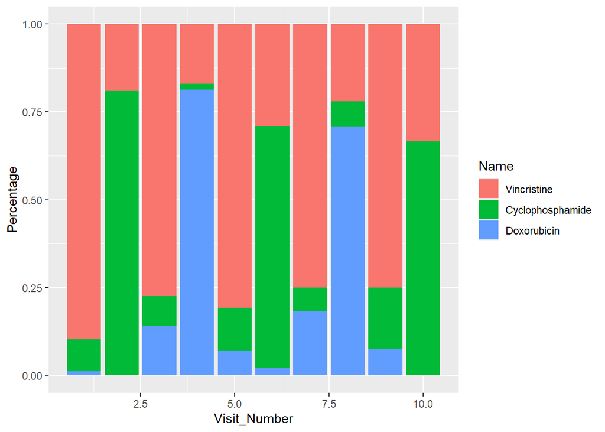

Figure 23: Distribution of Drug, by Visit

````markdown
```{r}
#| label: fig-visit-drug
#| fig-cap: Distribution of Drug, by Visit

Final_Visits %>%
  group_by(Visit_Number, Name, .drop = FALSE) %>%
  summarize(N = n()) %>%
  mutate(Percent = 100 * (N/sum(N))) %>%
  ungroup() %>%
  ggplot(., aes(fill = Name, y = Percent, x = Visit_Number)) +
  geom_bar(position = "fill", stat = "identity") +
  labs(y = "Percentage")
```
````

## 3.9 Sickness

This section includes summaries prepared as we were responding to a peer review comment about the possibility about dogs being sick was a possible confounder.

**Note**

Per Dr. Masyr, “illness, medication, and hospitalization details are most relevant for patients with bands. Clinically, we know that most patients feel well and do not require medical support at the time points we are monitoring.” Therefore, we added the `Sick_Type` and `Is_Sick` variables to the data to address the comment. These variables were only filled out for the observations where `Total_Bands` > 0 (equivalent to `Bands_Present = 1 (i.e., Yes)`). That is why there are lots of missing values for those variables.

Table 16 and Table 15 respectively showed frequency distributions for the categorical `Sick_Type` and binary `Bandemia` and `Is_Sick` variables over the entire dataset. Below, we focus on the data in the subset of observations where `Total_Bands` > 0 (equivalent to `Bands_Present = 1 (i.e., Yes)`).

````markdown
```{r}
#| label: create-Final-Visits-With-Bands

Final_Visits_With_Bands <- Final_Visits %>%
  filter(Total_Bands > 0)
```
````

Table 43 shows the 2 x 2 contingency table for `Is_Sick` and `Bandemia` among observations with bands present. We can derive several insights from this, starting with the overall rates of bandemia and sickness in this subset of the data. The Sum row at the bottom of that table shows that 67.3% of observations with any bands present had bandemia. Meanwhile the Sum column on the right side of the table shows the dog was sick in only 27.1% of observations with bands present. A chi-square test based on Table 43 faild to detect an association between being sick and having bandemia among observations where bands are present.

````markdown
```{r}
#| label: tbl-Is-Sick-Bandemia
#| tbl-cap: !expr paste0("Contingency Table for Is_Sick by Bandemia Among ",
#|                       "Observations With Total_Bands > 0 ",
#|                       "(N = ", nrow(Final_Visits_With_Bands), " Visits)")
#| results: asis
#| message: false

CT <- Final_Visits_With_Bands %>%
  xtabs(~Is_Sick + Bandemia, addNA = TRUE, data = .)
CT.CV <- cramers_v(x = CT, adjust = TRUE, ci = 0.95, alternative = "greater")

FN <- paste0("Chi-square test for independence, X^2(",
             chisq.test(x = CT)$parameter, ") = ",
             round(chisq.test(x = CT)$statistic, digits = 2),
             ", p = ", display_num(chisq.test(x = CT)$p.value), "; ",
             "Cramer's V (adjusted) = ",
             format(round(CT.CV$Cramers_v_adjusted, digits = 2), nsmall = 2),
             ", 1-tailed 95% CI = [",
             round(CT.CV$CI_low, digits = 2), ", ",
             format(CT.CV$CI_high, nsmall = 2), "].")

Final_Visits_With_Bands %>%
  mutate(Bandemia = factor(Bandemia, levels = 0:1, labels = c("No", "Yes")),
         Is_Sick = factor(Is_Sick, levels = 0:1, labels = c("No", "Yes"))) %>%
  xtabs(~Is_Sick + Bandemia, addNA = TRUE, data = .) %>%
  addmargins() %>%
  kable(digits = 1, col.names = c("Is Sick", "No", "Yes", "Sum")) %>%
  kable_styling() %>%
  add_header_above(header = c(" ", "Bandemia" = 2, " ")) %>%
  footnote(kable_input = ., general = FN, , footnote_as_chunk = TRUE) %>%
  cat()
```
````

Table 43: Contingency Table for Is_Sick by Bandemia Among Observations With Total_Bands > 0 (N = 107 Visits)

| Is Sick | Bandemia No | Bandemia Yes | Sum |
| --- | --- | --- | --- |
| No | 29 | 49 | 78 |
| Yes | 6 | 23 | 29 |
| Sum | 35 | 72 | 107 |

Note: Chi-square test for independence, X^2(1) = 1.92, p = 0.166; Cramer’s V (adjusted) = 0.12, 1-tailed 95% CI = [0, 1.00].

**Caution**

Based on data in Table 43, bandemia was detected in 62.8% of the observations where the dog was not sick and 79.3% of the observations where the dog was sick. This descriptively hints at a possible association between sickness and bandemia but the difference in these two bandemia rates was not large enough to be confident there is really an association according to the chi-square test result. Note that the confidence interval for Cramer’s V in Table 43 is so wide that it spans all possible values for that measure of association.

Table 44 shows a finer breakdown of the degree of sickness present in observations with bands present. We can see that a few observations came from sick dogs that improved without any medical intervention. Over half of the observations where some amount of sickness was present were treated with medication that did not include antibiotics. Only a small number of these observations were from dogs that were hospitalized due to sickness.

````markdown
```{r}
#| label: tbl-Sick-Type
#| tbl-cap: !expr paste0("Frequency Distribution for Sick_Type Among Observations ",
#|                       "With Total_Bands > 0 ",
#|                       "(N = ", nrow(Final_Visits_With_Bands), " Visits)")
#| results: asis
#| message: false

FN <- paste("Self-limited means the dog was sick but improved without",
            "intervention.",
            "Medicated means the dog received supportive medications for",
            "gastro-intestinal distress that did not include antibiotics.")

Final_Visits_With_Bands %>%
  count(Sick_Type) %>%
  mutate(Percent = 100*n/sum(n)) %>%
  kable(digits = 1) %>%
  kable_styling() %>%
  footnote(kable_input = ., general = FN, , footnote_as_chunk = TRUE) %>%
  cat()
```
````

Table 44: Frequency Distribution for Sick_Type Among Observations With Total_Bands > 0 (N = 107 Visits)

| Sick_Type | n | Percent |
| --- | --- | --- |
| Not sick | 78 | 72.9 |
| Self-limited | 5 | 4.7 |
| Medicated | 16 | 15.0 |
| Hospitalized | 8 | 7.5 |

Note: Self-limited means the dog was sick but improved without intervention. Medicated means the dog received supportive medications for gastro-intestinal distress that did not include antibiotics.

# 4 References

Eliason, C. N., Pierce, S. J., & Masyr, A. (2026). *Band neutrophils are observed in dogs undergoing multiagent chemotherapy including vincristine* [Manuscript accepted for publication]. Department of Small Animal Clinical Sciences, Michigan State University.

Pierce, S. J. (2026). *CHOPStudy: Research compendium for the CHOP study* (Version 1.0.0) [Reproducible Research Materials, Computer Program, R package, Public Repository]. GitHub. https://github.com/sjpierce/CHOPStudy

# 5 Software Information

This section documents information that is important for reproducibility. Most users will not need to read it. It is primarily here for use by the statistician on the team.

We used [R](https://www.r-project.org/) as our main computing environment and [Quarto](https://quarto.org/) scripts to enhance reproducibility. We used RStudio as the editor to interface with R and Quarto.

- Software chain: **qmd file > RStudio > Quarto > R > knitr > md file > Pandoc > HTML file**.
- Source file: **Descriptive_Analysis.qmd**
- Output file: **Descriptive_Analysis_2026-01-26.html**
- [Quarto 1.8.27](https://quarto.org/) runs `*.qmd` files through [R](https://www.r-project.org/) and [knitr](https://yihui.org/knitr/) to produce `*.md` markdown files.
- [Pandoc 3.6.3](https://pandoc.org) converts markdown files (`*.md`) to other formats, including LaTeX (`*.tex`) and HTML (`*.html`) among others.

## 5.2 Git Details

The current Git commit details and status are:

```r
git_report()
```

```
Local:    main P:/Consulting/Cases_1200-1399/C1358/CHOPStudy
Remote:   main @ origin (https://github.com/sjpierce/CHOPStudy.git)
Head:     [9cf15bd] 2026-01-26: Updated version & date.
```

```
Untracked files:
    Untracked:  data/Imported_CHOP_Data.RData
    Untracked:  scripts/Descriptive_Analysis.rmarkdown
    Untracked:  scripts/Descriptive_Analysis_files/
    Untracked:  scripts/Render_Scripts.rmarkdown
    Untracked:  scripts/output/CHOPStudy_output_2025-12-21.zip
    Untracked:  scripts/output/CHOPStudy_output_2026-01-17.zip

Unstaged changes:
    Modified:   NEWS.md
```